# ADSP 31014 Statistical Models for Data Science

Copyright © 2026 Danny Ng

November 10, 2026

# 1 Prerequisite

Here is a review of some prerequisite topics for this course.

## 1.1 Expectation

- Expectation $\mathbb{E}$ is always linear i.e. if $X_1,\dotsc,X_n$ are any random variables and $a_1,\dotsc,a_n$ are any constants, then
  $$\mathbb{E}(a_1
  X_1+\dotsb+a_n X_n) = a_1\mathbb{E}(X_1) + \dotsb +
  a_n\mathbb{E}(X_n)$$
- Special case #1: For linear (or affine) transformation of one random variable $X$,
  $$\mathbb{E}(aX+b) = a\,\mathbb{E}(X) +
  b$$
- If $X\perp Y$ are independent, then
  $$\mathbb{E}(XY) =
  \mathbb{E}(X)\,\mathbb{E}(Y)$$

## 1.2 Variance, Standard Deviation

- By definition,
  $$\begin{align}
  \text{Var}(X) &= \mathbb{E}(X - \mathbb{E}(X))^2 = \mathbb{E}(X^2) -
  (\mathbb{E}(X))^2\geq 0\\
  \text{SD}(X) &= \sqrt{\text{Var}(X)}\geq 0
  \end{align}$$
- If $X\equiv c$ is a constant i.e. not random, then it does not vary i.e.
  $$\text{Var}(c) = 0 = \text{SD}(c)$$
- If $X_1,\dotsc,X_n$ are any random variables and $a_1,\dotsc,a_n$ are any constants, then
  $$\text{Var}(a_1
  X_1+\dotsb+a_n X_n) = a_1^2\text{Var}(X_1) + \dotsb +
  a_n^2\text{Var}(X_n) + 2 \sum_{1\leq i < j\leq n}a_i
  a_j\text{Cov}(X_i, X_j)$$
- Special case #1: If $X_1,\dotsc,X_n$ are independent, then all $\text{Cov}(X_i, X_j)=0$ so
  $$\text{Var}(a_1 X_1+\dotsb+a_n X_n) =
  a_1^2\text{Var}(X_1) + \dotsb + a_n^2\text{Var}(X_n)$$
- Special case #2: For two random variables $X$ and $Y$,
  $$\text{Var}(X + Y) = \text{Var}(X) + \text{Var}(Y)
  + 2\,\text{Cov}(X,Y)$$
  This means whether the “variance of the sum” is larger (or smaller) than the “sum of the variances” depends on if $X$ and $Y$ are positively (or negatively) correlated.
- Special case #3: If $Y\equiv b$ is a constant, then $\text{Var}(b) = 0$ and $\text{Cov}(X,b) = 0$ so
  $$\begin{align}
  \text{Var}(aX+b) &= a^2\text{Var}(X)\\
  \text{SD}(aX+b) &= |a|\,\text{SD}(X)
  \end{align}$$
  In other words, variance and standard deviation are not affected by translation by $b$. But variance is in “squared unit of measurement” so it is scaled by $a^2$ instead of just $|a|$.

```r
x <- rnorm(5)
var(x)
var(x + 10)
var(10 * x)
```

```
[1] 0.8135283
[1] 0.8135283
[1] 81.35283
```

- If a random variable $X$ has finite variance $\text{Var}(X)<\infty$, then it will also have finite expectation $\left|\mathbb{E}(X)\right| <\infty$. Conversely, if a random variable $X$ does not have finite expectation i.e. $\mathbb{E}(X)=\infty$ or $-\infty$, then it will also have infinite variance $\text{Var}(X)=\infty$.

## 1.3 Covariance, Correlation

- By definition,
  $$\text{Cov}(X,Y) =
  \mathbb{E}\left((X-\mathbb{E}(X))(Y-\mathbb{E}(Y))\right) =
  \mathbb{E}(XY)-\mathbb{E}(X)\mathbb{E}(Y)$$
  $$\text{Corr}(X,Y) =
  \frac{\text{Cov}(X,Y)}{\text{SD}(X)\,\text{SD}(Y)}\in[-1,1]$$
- Variance is always self-covariance i.e.
  $$\begin{align}
  \text{Cov}(X, X) &= \text{Var}(X)\\
  \text{Corr}(X,X) &= 1
  \end{align}$$
- If $\text{Corr}(X,Y) = 1$, then $X$ and $Y$ are perfectly positively correlated. This only occurs when they are linearly related i.e. there exists some $a>0$ and $b$ such that
  $$X = aY + b$$
  Similarly, if $\text{Corr}(X,Y) = -1$, then $a < 0$.
- If $X\perp Y$ are independent random variables, then
  $$\text{Cov}(X,Y) = \mathbb{E}(XY) - \mathbb{E}(X)\mathbb{E}(Y) = 0$$

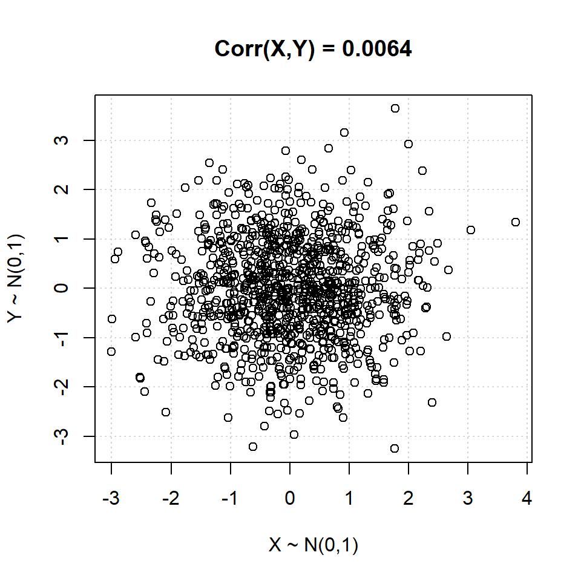

```r
n <- 1000
x <- rnorm(n)
y <- rnorm(n)

plot(x, y)
```

- But the converse is not true i.e. random variables can be uncorrelated but are still dependent. This is because covariance (and hence correlation) measures **linear association** only.

```r
n <- 100
x <- seq(-1, 1, length.out = n)
y <- x^2 + 0.05 * rnorm(n)
y <- y - sum(x * y) / sum(x * x) * x # Residual of orthogonal projection

cor(x, y)
```

```
[1] -1.451212e-16
```

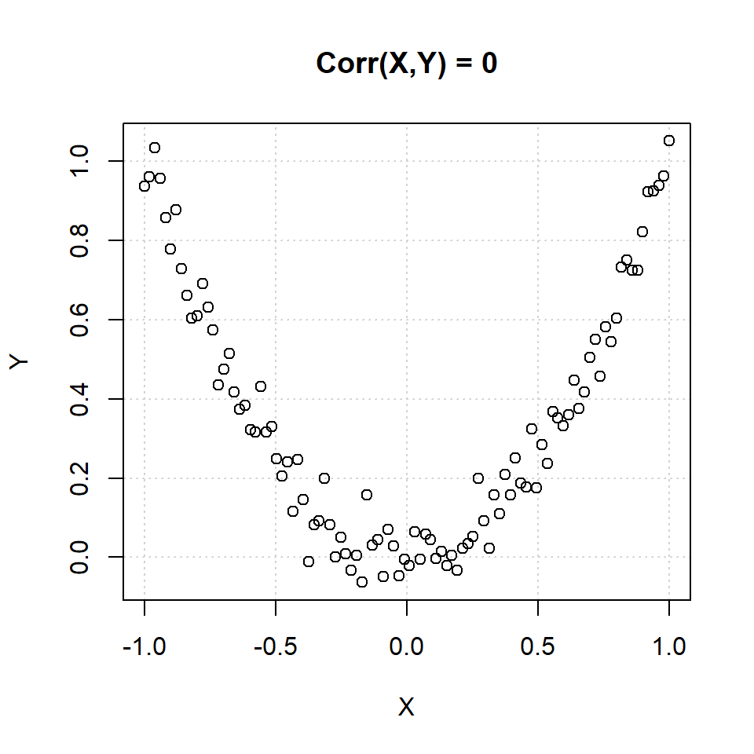

- If $Y\equiv c$ is a constant i.e. not random, then it is always independent of (and hence uncorrelated with) any other random variable $X$.
  $$\text{Cov}(X,c) = 0 =
  \text{Corr}(X,c)$$
- If $X_1,\dotsc,X_n,Y_1,\dotsc,Y_m$ are any random variables and $a_1,\dotsc,a_n,b_1,\dotsc,b_m$ are any constants, then
  $$\text{Cov}(a_1
  X_1+\dotsb+a_n X_n,\,b_1 Y_1+\dotsb+b_m Y_m) = \sum_{i=1}^n\sum_{j=1}^m
  a_i b_j \text{Cov}(X_i,Y_j)$$
- Special case #1: Since variance is self-covariance, all cases for variance above is a special case of this.
- Special case #2: For 4 random variables,
  $$\text{Cov}(X+Y,U+V) =
  \text{Cov}(X,U)+\text{Cov}(X,V)+\text{Cov}(Y,U)+\text{Cov}(Y,V)$$
- Special case #3: For positive linear (or affine) transformation with $a > 0$ and $c > 0$,
  $$\text{Corr}(aX+b, cY+d) =
  \text{Corr}(X,Y)$$
  In other words, correlation is not affected by translation or positive scaling.

```r
x <- rnorm(10)
y <- rnorm(10)
cor(x, y)
cor(2 * x + 3, 4 * y + 5)
```

```
[1] -0.3487052
[1] -0.3487052
```

```r
n <- 100
x <- runif(n, -1, 1)
y <- x + 0.5 * rnorm(n)

y1 <- y
y2 <- 2 * y
y3 <- 5 * y
```

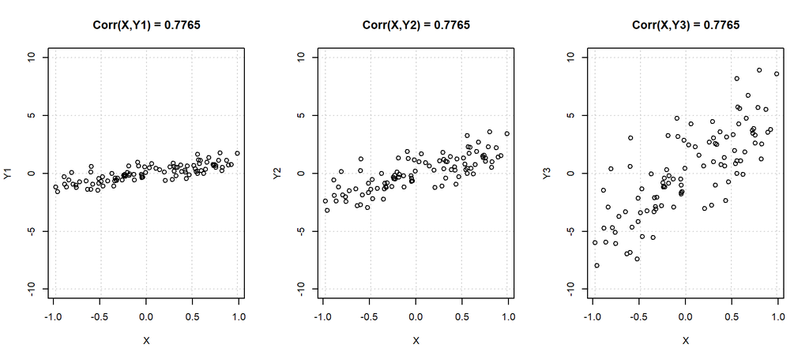

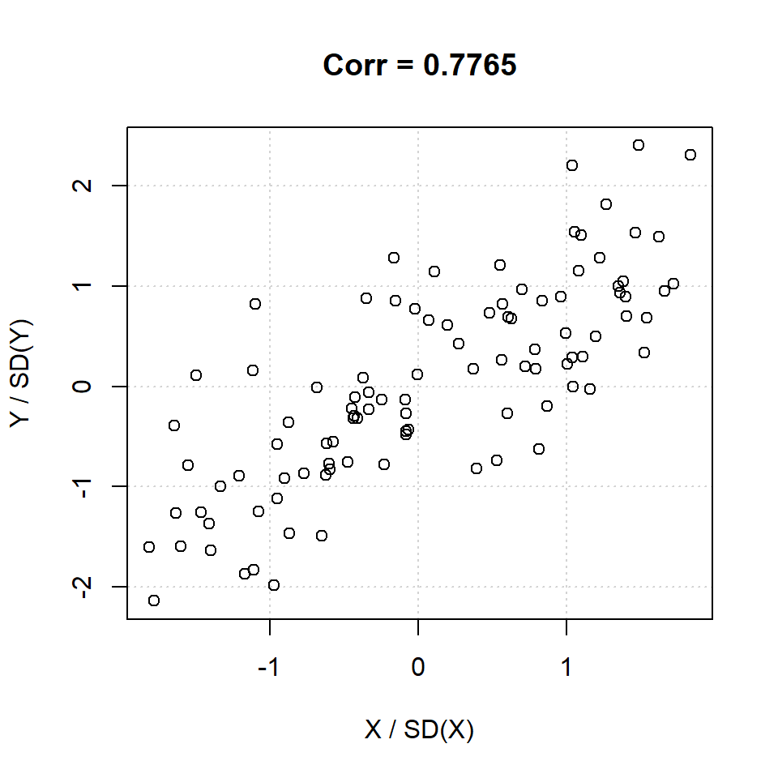

```r
plot(x / sd(x), y / sd(y))
```

```r
n <- 100
x <- runif(n, -1, 1)
noise <- rnorm(n)
y1 <- x + 5 * noise
y2 <- x + 0.8 * noise
y3 <- x + 0.3 * noise
```

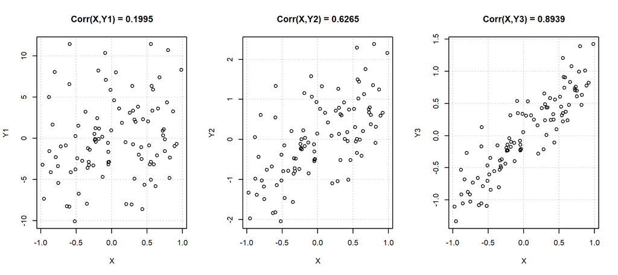

- In practice, $\text{Corr}(X,Y)\approx 0.6$ is a reasonably high correlation value.

# 2 Modeling

- We usually start with a set of $n$ observed **data points** $x_1,\dotsc,x_n$ or $n$ pairs of data $(x_1,y_1),\dotsc,(x_n,y_n)$. Sometimes each data point $x_i$ is not just a number but a $d$-dimensional vector $\vec{x}_i=(x_{i1},\dotsc,x_{id})\in\mathbb{R}^d$ with $d$ pieces of information.
- *Example:* $\vec{x}=\,$(age, sex, race, height, weight, blood pressure) and $y=\,$ cholesterol level
- A **model** is a simplified assumption about the underlying structure of the observed data.
- **Modeling** is the task of developing a suitable model that describes the observed data adequately. With this, we can:
  - Understand relationships within the data e.g. independence, low-dimensional
  - Perform clustering, dimension reduction, missing data imputation
  - Identify unusual observation / outlier / anomaly detection
  - Determine if a new observation is plausibly of the same kind
  - Predict / forecast the value of $y$ for some unseen value of $x$

## 2.1 Parametric vs Non-Parametric

- A **parametric model** is one in which the model can be parameterized (or completely described) by a fixed number of parameters $\theta$ irrespective of the number $n$ of observed data.
- *Example:* Let $x_1,\dotsc,x_n\in\{0,1\}$ be a sequence of observed coin tosses from a possibly unfair coin. We can model using a Bernoulli distribution $\text{Bern}(p)$ with parameter $\theta=p$ regardless of the number $n$ of tosses.
- *Example:* Let $x_1,\dotsc,x_n\in\mathbb{R}$ be the observed cholesterol level values of $n$ patients at a hospital. We can model using a normal distribution $\mathcal{N}(\mu,\sigma^2)$ with $2$-dimensional parameter $\theta=(\mu,\sigma^2)$.
- *Example:* Linear regression model assumes a linear relationship $y \approx \beta_0 + \beta_1 x_1 + \dotsb + \beta_d x_d$ between output $y$ and a number of inputs $x_1,\dotsc,x_d$ weighed by a fixed $d+1$ number of parameters $\beta_0,\dotsc,\beta_d$.
- A **non-parametric model** is one in which the number of parameters of the model increases with the number of observed data.
- *Example:* In machine learning, $k$-[nearest neighbors](https://en.wikipedia.org/wiki/K-nearest_neighbors_algorithm) $k$-NN algorithm whose model complexity is proportional to the number of observed data points, or [local regression](https://en.wikipedia.org/wiki/Local_regression) e.g. LOESS in which a separate regression model is fitted around each data point.
- In this course, we focus on parametric model.

# 3 Linear Regression Part 1

- Let $(\vec{x}_1,y_1),\dotsc,(\vec{x}_n,y_n)$ be $n$ pairs of observed data points. In general, the objective of **supervised** machine learning modeling is to learn a mathematical relationship $f$ between $\vec{x}$’s and **target label** $y$’s i.e.
  $$y = f(\vec{x}) + \epsilon$$
  In statistics, computer science, and machine learning literature and terminology:
  - $\vec{x}$ is the **explanatory** variable / **independent** variable / predictor / **covariate** / **input feature**. In general, $\vec{x}=(x_1,\dotsc,x_d)\in\mathbb{R}^d$ is a $d$-dimensional vector which represents $d$ pieces of information.
  - $y$ is the **response** variable / **dependent** variable / prediction / outcome / output.
  - $f$ is the model. In practice, it can be any mathematical function e.g. linear formula, decision tree, neural net, etc.
  - $\epsilon$ is the **error** / **residual** / **noise** that cannot be explained by the model $f$.
- If $y\in\mathbb{R}$ is numerical / quantitative / continuous, then it is a **regression** task. On the other hand, if $y\in\{c_1,\dotsc,c_k\}$ is a categorical / qualitative variable, then it is a **classification** task.

## 3.1 Linear Model

- For linear regression, the model $f$ represents a linear relationship between $\vec{x}$ and $y$ as follows:
  $$y = \underbrace{\beta_0 + \beta_1 x_1 + \dotsb +
  \beta_d x_d}_{f(\vec{x})} + \epsilon$$
  Here $\beta_0,\dotsc,\beta_d$ are the **coefficients** / parameters / **weights** of the model. They are unknown and to be estimated using the observed data.
- The model equation $f$ is “linear” because it involves a **linear combination** (in the sense of linear algebra) of the $d$ explanatory variables $x_1,\dotsc,x_d$.
- Interpretation of coefficient $\beta_j$: If $x_j$ increases by $+1$ unit to become $x_j + 1$, then $y$ should increase by $+\beta_j$ units.
- If $d = 1$ i.e. only one explanatory variable, then it is **simple linear regression**. Otherwise, if $d \geq 2$, then it is **multiple linear regression**.
- *Example:* The following model equation is still linear if we consider it as a relationship between $y$ and some new input features $x_3 = \log{x_1}$, $x_4 = (x_2)^2$, and $x_5 = x_1 x_2$.
  $$y = \beta_1 \underbrace{\log{x_1}}_{x_3} +
  \beta_2 \underbrace{(x_2)^2}_{x_4} + \beta_3 \underbrace{x_1 x_2}_{x_5}
  + \epsilon$$
- *Example:* The following model equation between $y$ and $x$ cannot be rewritten in the linear form so it is not a linear model.
  $$y = \beta_0 +
  \beta_1 x^{\beta_2} + \epsilon$$

## 3.2 Simple Linear Regression, Ordinary Least Squares

- How do we find the optimal $\beta_0^*,\dotsc,\beta_d^*$ parameters? Let’s start with simple linear regression.

```r
x <- c(0.4, 0.8, 1.2, 1.7, 2.1)
y <- c(2, 5, 4.3, 4.2, 8)
```

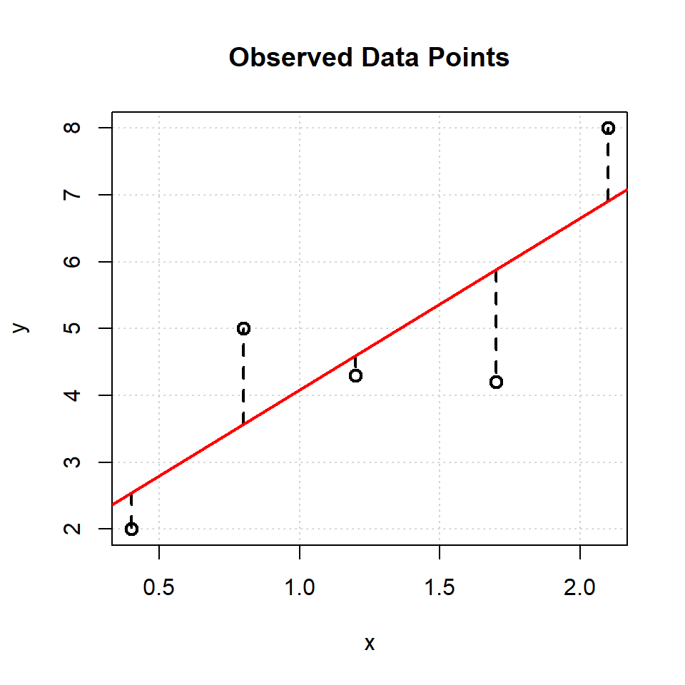

- Model equation is
  $$y =
  \underbrace{\beta_0 + \beta_1 x}_\text{line}+\epsilon$$
  with unknown intercept $\beta_0$ and slope $\beta_1$ parameters for the line.
- Let’s measure the **goodness-of-fit** of any particular line $y = \beta_0+ \beta_1 x$ based on the **mean squared error MSE** metric
  $$\text{MSE} = \frac{1}{n}\sum_{i=1}^n
  \big(\underbrace{y_i - (\overbrace{\beta_0 + \beta_1
  x_i}^{\text{predicted } \hat{y}_i})}_{\text{residual }r_i\text{ or error
  }e_i}\big)^2$$
  on the observed data. Here:
  - $\beta_0 + \beta_1 x_i$ is the **fitted** / **predicted value** (denoted by $\hat{y}_i$) along the line for the $i^\text{th}$ data point $x_i$.
  - $y_i - \hat{y}_i$ is the **residual** (denoted by $r_i$) or **error** (denoted by $e_i$) of the prediction. In the plot above, it corresponds to the vertical discrepancy between the observed **true value** / **ground truth** $y_i$ and the line.
  - MSE is the total discrepancy over the entire observed data set.
- Why do we use MSE? As an example, isn’t it simpler and more intuitive to use **mean absolute error MAE**
  $$\text{MAE} = \frac{1}{n}\sum_{i=1}^n \big|y_i -
  (\beta_0 + \beta_1 x_i)\big|$$
  instead? The main reason is that a quadratic function $f(x)=x^2$ is differentiable but an absolute value function $f(x)=|x|$ is not.
- If a residual $r_i$ has large (positive or negative) value, then its squared value $r_i^2$ is even larger. Therefore, MSE is easily impacted by an outlier. As a result, linear regression is not very robust against outliers.
- To find the optimal line and its intercept $\beta_0^*$ and slope $\beta_1^*$, the **ordinary least squares OLS** method seeks to minimize the MSE **loss** / **cost** / **objective function**
  $$\min_{\beta_0,\beta_1}\,\underbrace{\frac{1}{n}\sum_{i=1}^n
  \big(y_i - (\beta_0 + \beta_1 x_i)\big)^2}_\text{MSE}$$
  (In modern machine learning paradigm, this is a common approach to **learn** a model by optimizing a metric over a **training data** set.)
- By using calculus to differentiate the MSE with respect to its variables $\beta_0$ and $\beta_0$ and applying the [first-order condition](https://en.wikipedia.org/wiki/Derivative_test#First-derivative_test), we obtain the optimal slope parameter
  $$\beta_1^* = \frac{\sum_{i=1}^n
  (x_i-\bar{x}_n)(y_i-\bar{y}_n)}{\sum_{i=1}^n (x_i-\bar{x}_n)^2} =
  \frac{\text{Cov}(X,Y)}{\text{Var}(X)} =
  \text{Corr}(X,Y)\frac{\text{SD}(Y)}{\text{SD}(X)}$$
  and intercept parameter
  $$\beta_0^* = \bar{y}_n - \beta_1^*
  \bar{x}_n$$
  Note those are sample $\text{Cov}(\dotso)$, $\text{Var}(\dotso)$, and $\text{SD}(\dotso)$.
- In R, use built-in `lm()` function to fit linear regression model.

```r
model <- lm(y ~ x) # See ?formula for syntax

# Beta's
model
model$coefficients # See str(model)
coef(model)
coefficients(model)
summary(model)
```

```
Call:
lm(formula = y ~ x)

Coefficients:
(Intercept)            x
      1.513        2.570
```

```
(Intercept)           x
   1.512959    2.570194
```

```
(Intercept)           x
   1.512959    2.570194
```

```
(Intercept)           x
   1.512959    2.570194
```

```
Call:
lm(formula = y ~ x)

Residuals:
      1       2       3       4       5
-0.5410  1.4309 -0.2972 -1.6823  1.0896

Coefficients:
            Estimate Std. Error t value Pr(>|t|)
(Intercept)    1.513      1.488   1.017   0.3841
x              2.570      1.077   2.386   0.0971 .
---
Signif. codes:  0 '***' 0.001 '**' 0.01 '*' 0.05 '.' 0.1 ' ' 1

Residual standard error: 1.466 on 3 degrees of freedom
Multiple R-squared:  0.6549,    Adjusted R-squared:  0.5399
F-statistic: 5.694 on 1 and 3 DF,  p-value: 0.09707
```

```r
# Compute b0 and b1 manually
(b1 <- cov(x,y) / var(x)) # Same as cor(x, y) * sd(y) / sd(x)

x.bar <- mean(x)
y.bar <- mean(y)
(b0 <- y.bar - b1 * x.bar)
```

```
[1] 2.570194
[1] 1.512959
```

```r
# Fitted values / predictions
fitted(model)
fitted.values(model)
model$fitted.values
```

```
       1        2        3        4        5
2.541037 3.569114 4.597192 5.882289 6.910367
       1        2        3        4        5
2.541037 3.569114 4.597192 5.882289 6.910367
       1        2        3        4        5
2.541037 3.569114 4.597192 5.882289 6.910367
```

```r
# Residuals / errors
residuals(model) # Same as resid(model)
model$residuals
y - fitted(model)
```

```
         1          2          3          4          5
-0.5410367  1.4308855 -0.2971922 -1.6822894  1.0896328
         1          2          3          4          5
-0.5410367  1.4308855 -0.2971922 -1.6822894  1.0896328
         1          2          3          4          5
-0.5410367  1.4308855 -0.2971922 -1.6822894  1.0896328
```

```r
# Mean squared error MSE
mean(residuals(model) ^ 2)
deviance(model) / length(y)
```

```
[1] 1.289175
[1] 1.289175
```

- Linear regression model is effectively invariant to **affine transformation** $x\mapsto c_1 + c_2 x$ of an explanatory variable. In this case, the model prediction $\hat{y}$ does not change.
  - **Scaling:** If we scale an explanatory variable $x$ to become $c\,x$, then $\beta_1^*$ is scaled accordingly to become $(1/c)\,\beta_1^*$. But $\beta_0^*$ does not change.
  - **Translation:** If we translate an explanatory variable $x$ to become $x+c$, then $\beta_1^*$ does not change. Now $\beta_0^*$ becomes $\beta_0^* - \beta_1^*c$ to compensate.

```r
lm(y ~ x)

x10 <- x * 10
lm(y ~ x10) # b1 becomes 0.1 * b1

x2 <- x + 2
lm(y ~ x2) # b0 becomes b0 - 2 * b1
```

```
Call:
lm(formula = y ~ x)

Coefficients:
(Intercept)            x
      1.513        2.570
```

```
Call:
lm(formula = y ~ x10)

Coefficients:
(Intercept)          x10
      1.513        0.257
```

```
Call:
lm(formula = y ~ x2)

Coefficients:
(Intercept)           x2
     -3.627        2.570
```

- Based on the formulae for the optimal $\beta_0^*$ and $\beta_1^*$ parameters:
  - Re-arranging $\beta_0^*$ as
    $$\bar{y}_n = \beta_0^* + \beta_1^*
    \bar{x}_n$$
    shows that the optimal line $y = \beta_0^* + \beta_1^* x$ passes through the point $(\bar{x}_n, \bar{y}_n)$ which is the center of mass of all data points.
  - If we standardize each of the $x$’s and $y$’s to have mean $\bar{x}_n =\bar{y}_n=0$ and standard deviation $\text{SD}(X) = \text{SD}(Y) = 1$, then
    $$\beta_1^* =
    \text{Corr}(X,Y)\frac{\text{SD}(Y)}{\text{SD}(X)} =
    \text{Corr}(X,Y)\quad\text{and}\quad \beta_0^* = \bar{y}_n - \beta_1^*
    \bar{x}_n = 0$$
    This means the kind of linear relationship between $x$ and $y$ that is learned by the linear regression model (represented by $\beta_1^*$) is same as the kind of linear association described by their correlation $\text{Corr}(X,Y)$.

```r
x.std <- scale(x) # Standardize x
y.std <- scale(y)

lm(y.std ~ x.std) # Intercept b0 = 0 and slope b1 = cor(x, y)
cor(x, y)
```

```
Call:
lm(formula = y.std ~ x.std)

Coefficients:
(Intercept)        x.std
     0.0000       0.8093

[1] 0.8092785
```

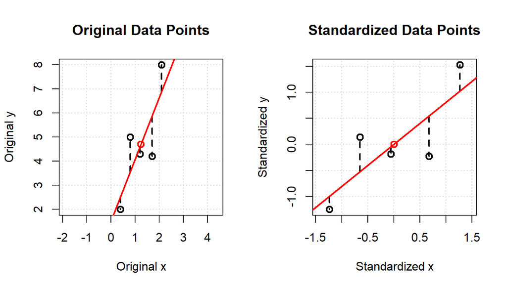

- In R, use `predict(..., newdata = ...)` function to predict on new explanatory data stored in a `data.frame()`.

```r
# Use predict()
model <- lm(y ~ x)
predict(model, newdata = data.frame(x=10))
```

```
      1
27.2149
```

```r
# Compute prediction manually
b0 <- coef(model)[1]
b1 <- coef(model)[2]
b0 + b1 * 10
```

```
(Intercept)
    27.2149
```

- In R, it is best practice to store the training data in a `data.frame()` and use the `lm(..., data = ...)` syntax. In this way, the fitted model remembers the naming and format of the explanatory variables from the data so `predict(..., newdata = ...)` knows how to extract the explanatory variables from new data of the same kind.

```r
data <- data.frame(x = c(0.4, 0.8, 1.2, 1.7, 2.1),
                   y = c(2, 5, 4.3, 4.2, 8))

model <- lm(y ~ x, data = data)
predict(model, newdata = data.frame(x = 10)) # Same format as training data
```

```
      1
27.2149
```

- If a model is not aware of the specific data format, then R cannot understand the structure of the new data. It would simply return the fitted values as predictions.

```r
model <- lm(data$y ~ data$x)
predict(model, newdata=data.frame(x = 10)) # Original fitted values
```

```
       1        2        3        4        5
2.541037 3.569114 4.597192 5.882289 6.910367
```

## 3.3 Multiple Linear Regression

- See `adsp31014_mlr.pdf`.

```r
x <- c(0.4, 0.8, 1.2, 1.7, 2.1)
y <- c(2, 5, 4.3, 4.2, 8)
model <- lm(y ~ x)

(X <- model.matrix(y ~ x)) # Design matrix with first column of 1's for intercept
```

```
  (Intercept)   x
1           1 0.4
2           1 0.8
3           1 1.2
4           1 1.7
5           1 2.1
attr(,"assign")
[1] 0 1
```

```r
(beta <- solve(t(X) %*% X, t(X) %*% y))
coef(model)
```

```
                [,1]
(Intercept) 1.512959
x           2.570194
(Intercept)           x
   1.512959    2.570194
```

```r
X %*% beta
fitted(model)
```

```
      [,1]
1 2.541037
2 3.569114
3 4.597192
4 5.882289
5 6.910367
       1        2        3        4        5
2.541037 3.569114 4.597192 5.882289 6.910367
```

## 3.4 Coefficient of Determination ${\small R^2}$

- The simplest linear regression model is the **null model** with only the intercept parameter $\beta_0$ and no explanatory variable i.e.
  $$y = \beta_0 + \epsilon$$
  In this case, the optimal intercept parameter $\beta_0^* = \bar{y}_n$ is simply the sample mean of the response values. As a result, the fitted / predicted value $\hat{y}_i = \beta_0^* = \bar{y}_n$ is a constant. The total error of this constant model on the observed data is
  $$SS_\text{total} =
  \sum_{i=1}^n (y_i - \bar{y}_n)^2$$
  This is called the **total sum of squares**. It represents the total amount of variation within the response values $y_1,\dotsc,y_n$.
- When we use a more sophisticated linear regression model with one or more explanatory variables i.e.
  $$y = \beta_0
  + \beta_1 x_1 + \dotsb + \beta_d x_d + \epsilon$$
  it can fit the observed data better i.e. $y_i \approx \hat{y}_i$ so the amount of error of this model
  $$SS_\text{error} = \sum_{i=1}^n (y_i -
  \hat{y}_i)^2 < SS_\text{total}$$
  is smaller than $SS_\text{total}$. This is called the **residual** / **error sum of squares** (sometimes denoted by $SS_\text{res}$). It represents the amount of variation in the response values that is unexplained by the explanatory variables.
- At the same time, each fitted value $\hat{y}_i$ is likely farther away from the overall mean $\bar{y}_n$. So the quantity
  $$SS_\text{reg} = \sum_{i=1}^n
  (\hat{y}_i - \bar{y}_n)^2 > 0$$
  increases. This is called the **model** / **regression sum of squares** (sometimes denoted by $SS_\text{model}$).
- Fact: We have the exact decomposition
  $$\underbrace{\sum_{i=1}^n (y_i -
  \bar{y}_n)^2}_{SS_\text{total}} = \underbrace{\sum_{i=1}^n (\hat{y}_i -
  \bar{y}_n)^2}_{SS_\text{reg}} + \underbrace{\sum_{i=1}^n (y_i -
  \hat{y}_i)^2}_{SS_\text{error}}$$
  (This is only true when the linear regression model has an intercept parameter.)
- This motivates us to measure the goodness-of-fit of a linear regression model based on the **coefficient of determination**
  $$R^2 =
  \frac{SS_\text{reg}}{SS_\text{total}} = 1 -
  \frac{SS_\text{error}}{SS_\text{total}}\in[0,1]$$
  (The definition of $R^2$ is slightly different for linear regression model without the intercept term. See R’s `?summary.lm` documentation. These two definitions are not comparable.) It represents the percentage / proportion of variation in the response variable that can be explained by the explanatory variables of the model.

```r
x <- c(0.4, 0.8, 1.2, 1.7, 2.1)
y <- c(2, 5, 4.3, 4.2, 8)
model <- lm(y ~ x)

# Compute various sums of squares
ss.total <- sum((y - mean(y)) ^ 2)
ss.reg <- sum((fitted(model) - mean(y)) ^ 2)
ss.error <- sum((y - fitted(model)) ^ 2) # Same as deviance(model)

c(ss.total, ss.reg, ss.error) # SST = SSR + SSE
```

```
[1] 18.680000 12.234125  6.445875
```

```r
# Coefficient of determination R^2
cor(y, fitted(model)) ^ 2
ss.reg / ss.total # SSR / SST
1 - ss.error / ss.total # 1 - SSE / SST
summary(model)$r.squared
```

```
[1] 0.6549318
[1] 0.6549318
[1] 0.6549318
[1] 0.6549318
```

- Note $0 < R^2 < 1$ is “normalized” in the sense that $SS_\text{reg}$ and $SS_\text{error}$ are benchmarked against $SS_\text{total}$ of the baseline constant model with only the intercept.
- If $R^2 \approx 1$, then $SS_\text{reg}\approx SS_\text{total}$ and $SS_\text{error}\approx 0$ so the model explains the response variable well. If $R^2 = 1$, then $SS_\text{error}= 0$ so all predictions are perfect i.e. $y_i = \hat{y}_i$ with no error or residual.
- If $R^2 = 0$, then the linear regression model does as poorly as the constant model with only the intercept.
- How is $R^2$ related to MSE? Since $\text{MSE} = SS_\text{error} / n$ and $SS_\text{total}=c$ is a constant that does not depend on any particular linear regression model, we have
  $$R^2 = 1 -
  \frac{SS_\text{error}}{SS_\text{total}} = 1 - \frac{\text{MSE}\times
  n}{c}$$
  So $R^2$ and MSE are equivalent metrics that are related monotonically i.e. if one increases, then the other one decreases.
- Fact: For linear regression model with intercept, we have
  $$R^2 = \text{Corr}(Y, \hat{Y})^2$$
  Note this is sample $\text{Corr}(...)$.

## 3.5 Multicollinearity

- In multiple linear regression, with many explanatory variables $\vec{x} = (x_1,\dotsc,x_d)$ in the model to explain the response variable $y$, there is a higher chance that some of these $d$ explanatory variable are correlated. In this case, $\vec{x}\in\mathbb{R}^d$ might not represent $d$ separate pieces of information i.e. there is some redundancy. This is called **multicollinearity**. (Note this concept is focused on the explanatory variables $x_1,\dotsc,x_d$ themselves and has nothing to do with the response variable $y$.)
- If two explanatory variables $x_1$ and $x_2$ are perfectly correlated i.e. $\text{Corr}(x_1, x_2) = 1$, then their roles are exchangeable. For example, if $x_1 = x$ and $x_2 = 4\,x$, then the model equation
  $$y = 4 \,x_1 + 0\,x_2 =
  0\, x_1 + 1\, x_2 = 2\, x_1 + 0.5\,x_2$$
  can be represented in (infinitely) many ways. The model is **non-identifiable** because of the non-uniqueness of the model parameters. (This is exactly the same as the concept of linear dependence of vectors in linear algebra.)

```r
x1 <- c(0.4, 0.8, 1.2, 1.7, 2.1)
y <- c(2, 5, 4.3, 4.2, 8)

x2 <- 2 * x1 # Corr(x1, x2) = 1
summary(lm(y ~ x1 + x2)) # Same as y ~ x1 + I(x1 * 2)   See ?formula
```

```
Call:
lm(formula = y ~ x1 + x2)

Residuals:
      1       2       3       4       5
-0.5410  1.4309 -0.2972 -1.6823  1.0896

Coefficients: (1 not defined because of singularities)
            Estimate Std. Error t value Pr(>|t|)
(Intercept)    1.513      1.488   1.017   0.3841
x1             2.570      1.077   2.386   0.0971 .
x2                NA         NA      NA       NA
---
Signif. codes:  0 '***' 0.001 '**' 0.01 '*' 0.05 '.' 0.1 ' ' 1

Residual standard error: 1.466 on 3 degrees of freedom
Multiple R-squared:  0.6549,    Adjusted R-squared:  0.5399
F-statistic: 5.694 on 1 and 3 DF,  p-value: 0.09707
```

- Multicollinearity makes numerical computation unstable. Parameter estimation becomes very sensitive i.e. a small change in an explanatory variable $x_i$ might result in a large change in the values of (more than one) model parameters. Consequently, the model has poor **explainability** because a $+1$ unit increase in an explanatory variable $x_i$ does not imply a $+\beta_i$ unit increase in the response variable $y$ anymore. (Part of the reason is because a change in $x_i$ will also imply a change in other highly correlated explanatory variables so the scenario of “$+1$ unit in $x_i$ while having all else being the same” does not hold.)

```r
set.seed(1)

x1 <- c(0.4, 0.8, 1.2, 1.7, 2.1)
y <- c(2, 5, 4.3, 4.2, 8)

x2 <- x1 + rnorm(length(x1), mean = 0, sd=1e-4) # Add small noise
x2
```

```
[1] 0.3999374 0.8000184 1.1999164 1.7001595 2.1000330
```

```r
1 - cor(x1, x2) # Corr(x1, x2) is almost 1
```

```
[1] 6.710243e-09
```

```r
summary(lm(y ~ x1 + x2)) # Large magnitude of parameters
```

```
Call:
lm(formula = y ~ x1 + x2)

Residuals:
      1       2       3       4       5
-0.5868  1.6740 -0.8504 -1.0331  0.7963

Coefficients:
              Estimate Std. Error t value Pr(>|t|)
(Intercept)     0.9954     1.9294   0.516    0.657
x1           5935.0921 10586.4781   0.561    0.631
x2          -5932.0427 10585.6229  -0.560    0.632

Residual standard error: 1.669 on 2 degrees of freedom
Multiple R-squared:  0.7018,    Adjusted R-squared:  0.4035
F-statistic: 2.353 on 2 and 2 DF,  p-value: 0.2982
```

```r
x3 <- x2
x3[2] <- x3[2] + 1e-5 # Small change in explanatory variable
x3
```

```
[1] 0.3999374 0.8000284 1.1999164 1.7001595 2.1000330
```

```r
summary(lm(y ~ x1 + x3)) # Parameters become sensitive
```

```
Call:
lm(formula = y ~ x1 + x3)

Residuals:
      1       2       3       4       5
-0.6016  1.6788 -0.7903 -1.1210  0.8341

Coefficients:
             Estimate Std. Error t value Pr(>|t|)
(Intercept)     1.087      1.929   0.564    0.630
x1           5174.437  10574.416   0.489    0.673
x3          -5171.461  10573.587  -0.489    0.673

Residual standard error: 1.697 on 2 degrees of freedom
Multiple R-squared:  0.6918,    Adjusted R-squared:  0.3836
F-statistic: 2.245 on 2 and 2 DF,  p-value: 0.3082
```

- In general, multicollinearity can occur when one explanatory variable is correlated with a mix of a few other explanatory variables i.e. not just between a pair of two explanatory variables.

```r
set.seed(1)

n <- 5
m <- matrix(rnorm(n * 2), nrow = n, ncol = 2) %*% matrix(c(2, 0, -2, 3), nrow = 2, ncol = 2)
x1 <- m[,1]
x2 <- m[,2]

x1
x2
cor(x1, x2) # Not very correlated
```

```
[1] -1.2529076  0.3672866 -1.6712572  3.1905616  0.6590155
[1] -1.208498  1.095001  3.886231 -1.463218 -1.575181
[1] -0.5773345
```

```r
# Construct y
y <- 1 + 2 * x1 + 3 * x2 + rnorm(n, mean = 0, sd = 0.1)

lm(y ~ x1 + x2)
```

```
Call:
lm(formula = y ~ x1 + x2)

Coefficients:
(Intercept)           x1           x2
      1.033        1.917        2.950
```

```r
set.seed(2)

x3 <- x1 + 0.8 * x2 + rnorm(n, mean = 0, sd =1e-3)

x3
cor(x1, x3) # Not very correlated
cor(x2, x3)
cor(x3, x1 + 0.8 * x2) # Multicollinear
```

```
[1] -2.2206026  1.2434719  1.4393157  2.0188572 -0.6012093
[1] 0.4745505
[1] 0.4447389
[1] 0.9999998
```

```r
summary(lm(y ~ x1 + x2 + x3))
```

```
Call:
lm(formula = y ~ x1 + x2 + x3)

Residuals:
         1          2          3          4          5
-0.0116829  0.1002917 -0.0474113 -0.0409079 -0.0002896

Coefficients:
             Estimate Std. Error t value Pr(>|t|)
(Intercept)   1.04151    0.05671  18.367   0.0346 *
x1          -81.61755  141.49937  -0.577   0.6669
x2          -63.91393  113.26165  -0.564   0.6729
x3           83.53995  141.50896   0.590   0.6605
---
Signif. codes:  0 '***' 0.001 '**' 0.01 '*' 0.05 '.' 0.1 ' ' 1

Residual standard error: 0.1188 on 1 degrees of freedom
Multiple R-squared:  0.9999,    Adjusted R-squared:  0.9996
F-statistic:  3063 on 3 and 1 DF,  p-value: 0.01328
```

- How to detect general multicollinearity?
  1. For each explanatory variable $x_i$, we fit a multiple regression model with $x_i$ as the response variable to see how much it can be explained by the other explanatory variables $x_1,\dotsc,x_{i-1},x_{i+1},\dotsc,x_d$.
  2. If the linear regression model $R^2$ is high, then the model has found a linear combination of the other explanatory variables that together is highly (in fact, highest) correlated with $x_i$.
  3. Compute the **variance inflation factor VIF**
     $$\text{VIF} =
     \frac{1}{1-R^2}\in[1,\infty)$$
  4. In practice, if $\text{VIF}>5$ i.e. $R^2 > 0.8$ or correlation $|R| > 0.89$, then there is strong evidence of multicollinearity. In this case, we should consider omitting the explanatory variable $x_i$ from the modeling.

```r
(r2 <- summary(lm(x3 ~ x1 + x2))$r.squared)
(vif <- 1 / (1 - r2))
```

```
[1] 0.9999999
[1] 17419081
```

- Note the VIF procedure tells us if one explanatory variable is redundant when all the other explanatory variables already exist in the model. If two explanatory variables are highly correlated with each other, then they would both have high VIF values. But it doesn’t mean you should simply omit both variables from modeling. Perhaps you need to keep one of them.
- Although multicollinearity often affects the estimation of model parameters (and hence model explainability and identifiability), it usually DOES NOT affect the goodness-of-fit of the model (as measured by MSE or $R^2$) or prediction.

```r
set.seed(1)

n <- 100
x1 <- rnorm(n)
y <- 1 + 2 * x1 + rnorm(n)

m1 <- lm(y ~ x1)
summary(m1)
```

```
Call:
lm(formula = y ~ x1)

Residuals:
    Min      1Q  Median      3Q     Max
-1.8768 -0.6138 -0.1395  0.5394  2.3462

Coefficients:
            Estimate Std. Error t value Pr(>|t|)
(Intercept)  0.96231    0.09699   9.922   <2e-16 ***
x1           1.99894    0.10773  18.556   <2e-16 ***
---
Signif. codes:  0 '***' 0.001 '**' 0.01 '*' 0.05 '.' 0.1 ' ' 1

Residual standard error: 0.9628 on 98 degrees of freedom
Multiple R-squared:  0.7784,    Adjusted R-squared:  0.7762
F-statistic: 344.3 on 1 and 98 DF,  p-value: < 2.2e-16
```

```r
predict(m1, newdata = data.frame(x1 = 10))
```

```
      1
20.9517
```

```r
set.seed(2)

x2 <- 2 * x1 + rnorm(n, mean = 0, sd=1e-4)

m2 <- lm(y ~ x1 + x2)
summary(m2)
```

```
Call:
lm(formula = y ~ x1 + x2)

Residuals:
    Min      1Q  Median      3Q     Max
-1.8836 -0.6172 -0.1165  0.5317  2.3326

Coefficients:
              Estimate Std. Error t value Pr(>|t|)
(Intercept)    0.96216    0.09747   9.871 2.54e-16 ***
x1           334.18210 1696.40039   0.197    0.844
x2          -166.09323  848.20862  -0.196    0.845
---
Signif. codes:  0 '***' 0.001 '**' 0.01 '*' 0.05 '.' 0.1 ' ' 1

Residual standard error: 0.9675 on 97 degrees of freedom
Multiple R-squared:  0.7785,    Adjusted R-squared:  0.774
F-statistic: 170.5 on 2 and 97 DF,  p-value: < 2.2e-16
```

```r
predict(m2, newdata = data.frame(x1 = 10, x2 = 20))
```

```
       1
20.91857
```

## 3.6 Polynomial Regression

- If the relationship between the observed response $y$ and an explanatory variable $x$ looks like a higher-degree polynomial instead of a straight line, then we could do **feature engineering** to construct additional explanatory variables for the higher-order terms e.g.
  $$x_1 = x,\,x_2
  = x^2,\,x_3=x^3,\,\dotsc,\,x_p= x^p$$
  The resulting linear regression model
  $$y = \beta_0 + \beta_1 x_1
  + \beta_2 x_2 + \dotsc + \beta_p x_p +\epsilon$$
  is essentially fitting a $p^\text{th}$ degree polynomial curve to the original observed data $x$ and $y$ i.e.
  $$y =
  \beta_0 + \beta_1 x + \beta_2 x^2 + \dotsc + \beta_p x^p
  +\epsilon$$
- Such **polynomial regression** is still considered a “linear” regression model in the sense that it involves a linear combination of the explanatory variables. It just happens that these explanatory variables $x_1,\,x_2,\,\dotsc$ are related to each other.

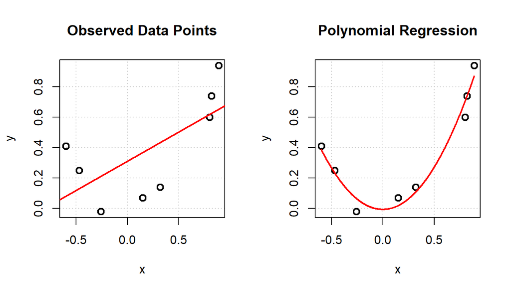

```r
x <- c(-0.47, -0.26, 0.15, 0.82, -0.6, 0.80, 0.89, 0.32)
y <- c(0.25, -0.02, 0.07, 0.74, 0.41, 0.60, 0.94, 0.14)

plot(x, y, type = 'p')
abline(lm(y ~ x), col='red')

plot(x, y, type = 'p')
model <- lm(y ~ x + I(x ^ 2))
xticks <- seq(from = min(x), to = max(x), length.out = 1000)
lines(xticks, predict(model, newdata = data.frame(x = xticks)), col='red')
```

```r
summary(model)
```

```
Call:
lm(formula = y ~ x + I(x^2))

Residuals:
        1         2         3         4         5         6         7         8
 0.015154 -0.087275  0.050159  0.001398  0.022780 -0.102841  0.069301  0.031323

Coefficients:
             Estimate Std. Error t value Pr(>|t|)
(Intercept) -0.005722   0.045619  -0.125 0.905069
x            0.005357   0.063302   0.085 0.935845
I(x^2)       1.100433   0.125286   8.783 0.000317 ***
---
Signif. codes:  0 '***' 0.001 '**' 0.01 '*' 0.05 '.' 0.1 ' ' 1

Residual standard error: 0.07382 on 5 degrees of freedom
Multiple R-squared:  0.9669,    Adjusted R-squared:  0.9536
F-statistic: 72.94 on 2 and 5 DF,  p-value: 0.0001999
```

- In R, we can use either `I(x ^ p)` or `poly(x, p, raw = TRUE)` syntax to construct polynomial variables. Note `x ^ p` without `I()` does not work because it is for variable interaction later. For `poly()` function, we need `raw = TRUE` because otherwise it would construct the “orthogonal” version which is a complicated topic in [experimental design](https://en.wikipedia.org/wiki/Design_of_experiments).

```r
poly(x, 2, raw = TRUE)
```

```
         1      2
[1,] -0.47 0.2209
[2,] -0.26 0.0676
[3,]  0.15 0.0225
[4,]  0.82 0.6724
[5,] -0.60 0.3600
[6,]  0.80 0.6400
[7,]  0.89 0.7921
[8,]  0.32 0.1024
attr(,"degree")
[1] 1 2
attr(,"class")
[1] "poly"   "matrix"
```

```r
summary(lm(y ~ poly(x, 2, raw = TRUE))) # Same as lm(y ~ x + I(x ^ 2))
```

```
Call:
lm(formula = y ~ poly(x, 2, raw = TRUE))

Residuals:
        1         2         3         4         5         6         7         8
 0.015154 -0.087275  0.050159  0.001398  0.022780 -0.102841  0.069301  0.031323

Coefficients:
                         Estimate Std. Error t value Pr(>|t|)
(Intercept)             -0.005722   0.045619  -0.125 0.905069
poly(x, 2, raw = TRUE)1  0.005357   0.063302   0.085 0.935845
poly(x, 2, raw = TRUE)2  1.100433   0.125286   8.783 0.000317 ***
---
Signif. codes:  0 '***' 0.001 '**' 0.01 '*' 0.05 '.' 0.1 ' ' 1

Residual standard error: 0.07382 on 5 degrees of freedom
Multiple R-squared:  0.9669,    Adjusted R-squared:  0.9536
F-statistic: 72.94 on 2 and 5 DF,  p-value: 0.0001999
```

- In the example above, the observed data were simulated from a pure quadratic function $y = x^2 + \epsilon$ with noise $\epsilon\sim\mathcal{N}(0, 0.01)$. The estimated intercept $\beta_0^* \approx 0$ and linear term $\beta_1^*\approx 0$ are both close to 0. Nonetheless, we should still fit the full quadratic model (with intercept and linear terms)
  $$y = \beta_0 + \beta_1 x + \beta_2 x^2 +
  \epsilon$$
  instead of the pure quadratic model
  $$y = \beta_2 x^2 +\epsilon$$

```r
summary(lm(y ~ 0 + I(x ^ 2))) # Same as lm(y ~ I(x ^ 2) - 1)
```

```
Call:
lm(formula = y ~ 0 + I(x^2))

Residuals:
     Min       1Q   Median       3Q      Max
-0.10100 -0.02088  0.01187  0.03222  0.07240

Coefficients:
       Estimate Std. Error t value Pr(>|t|)
I(x^2)  1.09532    0.04826    22.7 8.17e-08 ***
---
Signif. codes:  0 '***' 0.001 '**' 0.01 '*' 0.05 '.' 0.1 ' ' 1

Residual standard error: 0.06261 on 7 degrees of freedom
Multiple R-squared:  0.9866,    Adjusted R-squared:  0.9847
F-statistic: 515.1 on 1 and 7 DF,  p-value: 8.166e-08
```

- Why? If we apply an affine transformation $x\mapsto x+1$ to transform the explanatory variable, then the relationship between $y$ and $x$ becomes
  $$y
  = \beta_2 (x + 1)^2 + \epsilon = \beta_2 + 2 \beta_2 x + \beta_2 x^2 +
  \epsilon$$
  The lower-degree terms (i.e. intercept and linear terms) re-appear. Therefore, in order to preserve the invariance property of linear regression model with respect to affine transformation, it is best practice to keep all lower-degree terms $x^0=1,\,x,\,x^2,\dotsc,\,x^{p-1}$ up to the highest degree $x^p$ of our polynomial regression. (This continues to hold when we consider higher-order interaction terms later.)

## 3.7 Categorical Variable

- In order to use a categorical explanatory variable in machine learning modeling (including linear regression), it needs to be converted to numerical values first. Some common techniques are:
  1. **Label encoding**: Convert to an integer index $x\in\{1,\dotsc,K\}$ or $x\in\{0,\dotsc,K-1\}$ to represent one of the $K$ categorical levels / classes.
  2. [**One-hot encoding**](https://en.wikipedia.org/wiki/One-hot) / **dummy variable**: Convert to a $K$-dimensional binary vector $\vec{x}=(0,\dotsc,0,1,0,\dotsc,0)\in\{0,1\}^K$ with the position of $1$ to indicate the categorical level.
  3. Dense **embedding vector** representation $\vec{x}\in\mathbb{R}^d$ (mostly used in neural net)
- In R, the `factor(..., levels = ..., labels = ...)` function performs label encoding. (In Python, use the `sklearn.preprocessing.OrdinalEncoder()` function.)

```r
blood <- c('A', 'O', 'AB', 'B', 'A', 'O', 'O', 'B', 'AB')

str(blood)
```

```
 chr [1:9] "A" "O" "AB" "B" "A" "O" "O" "B" "AB"
```

```r
blood.f <- factor(blood)

blood.f
str(blood.f)
```

```
[1] A  O  AB B  A  O  O  B  AB
Levels: A AB B O
 Factor w/ 4 levels "A","AB","B","O": 1 4 2 3 1 4 4 3 2
```

```r
levels(blood.f)
nlevels(blood.f)
as.character(blood.f)
as.numeric(blood.f)
```

```
[1] "A"  "AB" "B"  "O"
[1] 4
[1] "A"  "O"  "AB" "B"  "A"  "O"  "O"  "B"  "AB"
[1] 1 4 2 3 1 4 4 3 2
```

- In R, the factor levels are `sort(unique(x))` by default so the alphabetically smallest categorical level becomes the first **baseline** level. This plays a role in linear regression modeling later. To modify the baseline level, use the `relevel()` function.

```r
blood.f <- relevel(blood.f, 'AB') # AB = 1, A = 2, B = 3, O = 4

blood.f
```

```
[1] A  O  AB B  A  O  O  B  AB
Levels: AB A B O
```

- To specify a custom ordering of the categorical levels, use `factor(..., levels = ...)`.

```r
blood.f <- factor(blood, levels = c('O', 'AB', 'A', 'B')) # O = 1, AB = 2, BA = 3, B = 4

blood.f
```

```
[1] A  O  AB B  A  O  O  B  AB
Levels: O AB A B
```

- *Example:* We collect the actual temperature, feel-like temperature, and weather condition (either “Sunny” or “Windy”) data on 10 days.

```r
data <- data.frame(temperature = c(57, 75, 71, 56, 84, 84, 55, 80, 67, 70),
                   weather = rep(c('Sunny', 'Windy'), each = 5),
                   feel = c(69, 92, 86, 70, 102, 67, 44, 63, 51, 57))
```

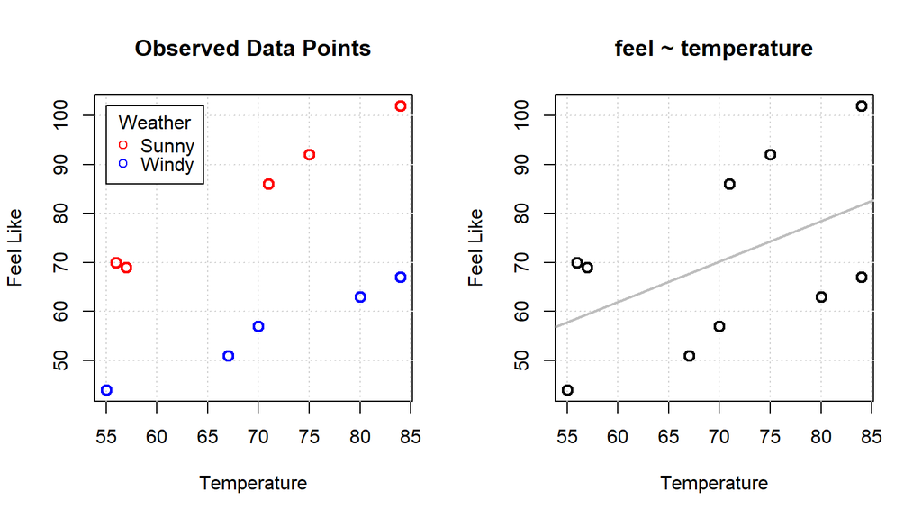

- If we fit a linear regression model to all the observed data (without considering `weather` explicitly), then the model equation is
  $$(\text{feel}) = 12.39 +
  0.83\,(\text{temperature})$$

```r
summary(lm(feel ~ temperature, data = data))
```

```
Call:
lm(formula = feel ~ temperature, data = data)

Residuals:
    Min      1Q  Median      3Q     Max
-16.706 -14.505  -1.816  14.088  20.259

Coefficients:
            Estimate Std. Error t value Pr(>|t|)
(Intercept)  12.3914    35.6138   0.348    0.737
temperature   0.8256     0.5038   1.639    0.140

Residual standard error: 16.84 on 8 degrees of freedom
Multiple R-squared:  0.2513,    Adjusted R-squared:  0.1578
F-statistic: 2.686 on 1 and 8 DF,  p-value: 0.1399
```

- One way to include a categorical explanatory variable in a linear regression model is as an additive term e.g. `+ weather`. In the case when there are only 2 categorical levels, this represents one (numerical) binary indicator variable
  $$x_2 = \mathbf{1}_{\{\text{Windy}\}} =
  \begin{cases}
  1 & \text{if Windy}\\
  0 & \text{if Sunny}
  \end{cases}$$
  This is denoted by `weatherWindy` in R’s model `summary()` output.

```r
summary(lm(feel ~ temperature + weather, data = data))
```

```
Call:
lm(formula = feel ~ temperature + weather, data = data)

Residuals:
    Min      1Q  Median      3Q     Max
-3.1979 -1.9510 -0.6991  1.7999  3.8029

Coefficients:
              Estimate Std. Error t value Pr(>|t|)
(Intercept)   15.18753    5.74546   2.643   0.0333 *
temperature    1.00018    0.08186  12.218 5.63e-06 ***
weatherWindy -30.00047    1.73028 -17.339 5.22e-07 ***
---
Signif. codes:  0 '***' 0.001 '**' 0.01 '*' 0.05 '.' 0.1 ' ' 1

Residual standard error: 2.715 on 7 degrees of freedom
Multiple R-squared:  0.983, Adjusted R-squared:  0.9781
F-statistic: 201.9 on 2 and 7 DF,  p-value: 6.453e-07
```

- The model equation is
  $$\begin{align}
  (\text{feel})
  &= 15.19 + 1.00\,(\text{temperature}) -
  30.00\,\mathbf{1}_{\{\text{Windy}\}}\\
  &=\begin{cases}
  15.19 + 1.00\,(\text{temperature}) & \text{if Sunny}\\
  -14.81 + 1.00\,(\text{temperature}) & \text{if Windy}
  \end{cases}
  \end{align}$$
  It essentially fits two separate lines with the same slope $\beta_1$ but different intercepts $\beta_0$ vs $\beta_0+\beta_2$ to the observed data.

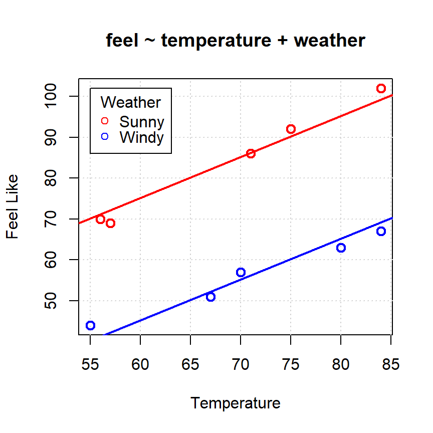

- Here $\beta_0$ is the intercept for the “Sunny” group while $\beta_2$ is the increment (or decrement) of the intercept of the “Windy” group relative to the “Sunny” group. In this sense, the “Sunny” group is the baseline. However, there is nothing intrinsically special about the baseline group. “Sunny” is selected as the baseline merely because it is the first level in `factor(weather)`.
- If we `relevel()` to “Windy” first, then the model equation becomes
  $$\begin{align}
  (\text{feel})
  &= -14.81 + 1.00\,(\text{temperature}) +
  30.00\,\mathbf{1}_{\{\text{Sunny}\}}\\
  &=\begin{cases}
  -14.81 + 1.00\,(\text{temperature}) & \text{if Windy}\\
  15.19 + 1.00\,(\text{temperature}) & \text{if Sunny}
  \end{cases}
  \end{align}$$
  It is equivalent to the previous model equation.

```r
(data$weather <- relevel(factor(data$weather), 'Windy'))
```

```
 [1] Sunny Sunny Sunny Sunny Sunny Windy Windy Windy Windy Windy
Levels: Windy Sunny
```

```r
summary(lm(feel ~ temperature + weather, data = data))
```

```
Call:
lm(formula = feel ~ temperature + weather, data = data)

Residuals:
    Min      1Q  Median      3Q     Max
-3.1979 -1.9510 -0.6991  1.7999  3.8029

Coefficients:
              Estimate Std. Error t value Pr(>|t|)
(Intercept)  -14.81295    5.95366  -2.488   0.0417 *
temperature    1.00018    0.08186  12.218 5.63e-06 ***
weatherSunny  30.00047    1.73028  17.339 5.22e-07 ***
---
Signif. codes:  0 '***' 0.001 '**' 0.01 '*' 0.05 '.' 0.1 ' ' 1

Residual standard error: 2.715 on 7 degrees of freedom
Multiple R-squared:  0.983, Adjusted R-squared:  0.9781
F-statistic: 201.9 on 2 and 7 DF,  p-value: 6.453e-07
```

- Another way to fit the same linear regression model is to omit the default intercept term $\beta_0$ by either specifying `0 +` or `- 1` in R’s formula. The model equation is
  $$(\text{feel})
  = 0 + 1.00\,(\text{temperature}) - 14.81 \,\mathbf{1}_{\{\text{Windy}\}}
  + 15.19 \,\mathbf{1}_{\{\text{Sunny}\}}$$
  which has separate intercepts $\beta_2$ and $\beta_3$ for each `weather` group explicitly without one particular group as the baseline.

```r
summary(lm(feel ~ 0 + temperature + weather, data = data))
```

```
Call:
lm(formula = feel ~ 0 + temperature + weather, data = data)

Residuals:
    Min      1Q  Median      3Q     Max
-3.1979 -1.9510 -0.6991  1.7999  3.8029

Coefficients:
              Estimate Std. Error t value Pr(>|t|)
temperature    1.00018    0.08186  12.218 5.63e-06 ***
weatherWindy -14.81295    5.95366  -2.488   0.0417 *
weatherSunny  15.18753    5.74546   2.643   0.0333 *
---
Signif. codes:  0 '***' 0.001 '**' 0.01 '*' 0.05 '.' 0.1 ' ' 1

Residual standard error: 2.715 on 7 degrees of freedom
Multiple R-squared:  0.999, Adjusted R-squared:  0.9986
F-statistic:  2357 on 3 and 7 DF,  p-value: 7.082e-11
```

- In this case, the design matrix $X\in\mathbb{R}^{10\times 3}$ does not have a first column of 1’s anymore. Instead, it has 2 columns of binary indicator variables
  $$x_2 = \mathbf{1}_{\{\text{Windy}\}} =
  \begin{cases}
  1 & \text{if Windy}\\
  0 & \text{if Sunny}
  \end{cases}
  \quad
  \quad
  x_3 = \mathbf{1}_{\{\text{Sunny}\}} =
  \begin{cases}
  1 & \text{if Sunny}\\
  0 & \text{if Windy}
  \end{cases}$$
  Together, they form the one-hot encoding / dummy variables of the `weather` categorical variable. (In Python, use `sklearn.preprocessing.OneHotEncoder()` or `pandas.get_dummies()` functions.)

```r
(X <- model.matrix(feel ~ 0 + temperature + weather, data = data))
```

```
   temperature weatherWindy weatherSunny
1           57            0            1
2           75            0            1
3           71            0            1
4           56            0            1
5           84            0            1
6           84            1            0
7           55            1            0
8           80            1            0
9           67            1            0
10          70            1            0
attr(,"assign")
[1] 1 2 2
attr(,"contrasts")
attr(,"contrasts")$weather
[1] "contr.treatment"
```

- Why not have both the (constant) intercept variable $x_0 = 1$ along with one-hot encoding of all levels $x_2 = \mathbf{1}_{\{\text{Windy}\}}$ and $x_3=\mathbf{1}_{\{\text{Sunny}\}}$ of a categorical variable in the model equation?
  $$(\text{feel})
  = \beta_0 + \beta_1\,(\text{temperature}) +\beta_2
  \,\mathbf{1}_{\{\text{Windy}\}} + \beta_3
  \,\mathbf{1}_{\{\text{Sunny}\}}$$
  It would have multicollinearity because
  $$x_0 = 1 =
  \mathbf{1}_{\{\text{Windy}\}} + \mathbf{1}_{\{\text{Sunny}\}} = x_2 +
  x_3$$
  In this case, the model would be **over-parameterized** / **unidentifiable** because the intercepts for the two groups are now $\beta_0 + \beta_2$ and $\beta_0 + \beta_3$ which have no unique optimal parameters.
- In summary, for categorical variable, we must drop either one level of the one-hot encoding or the default intercept in our design matrix $X$.
- What if we fit a linear regression model with only a categorical variable?
  $$(\text{feel})
  = 0 + \beta_1 \,\mathbf{1}_{\{\text{Windy}\}} + \beta_2
  \,\mathbf{1}_{\{\text{Sunny}\}}$$
  In statistics literature, this is called a **fixed-effect** model.

```r
summary(lm(feel ~ 0 + weather, data = data))
```

```
Call:
lm(formula = feel ~ 0 + weather, data = data)

Residuals:
   Min     1Q Median     3Q    Max
-14.80 -10.65   1.40   7.80  18.20

Coefficients:
             Estimate Std. Error t value Pr(>|t|)
weatherWindy   56.400      5.367   10.51 5.85e-06 ***
weatherSunny   83.800      5.367   15.62 2.82e-07 ***
---
Signif. codes:  0 '***' 0.001 '**' 0.01 '*' 0.05 '.' 0.1 ' ' 1

Residual standard error: 12 on 8 degrees of freedom
Multiple R-squared:  0.9779,    Adjusted R-squared:  0.9724
F-statistic: 177.1 on 2 and 8 DF,  p-value: 2.378e-07
```

- The optimal intercept parameters $\beta_1^*$ and $\beta_2^*$ are simply the per-group sample means.

```r
aggregate(feel ~ weather, data = data, mean) # with(data, tapply(feel, weather, mean))
```

```
  weather feel
1   Windy 56.4
2   Sunny 83.8
```

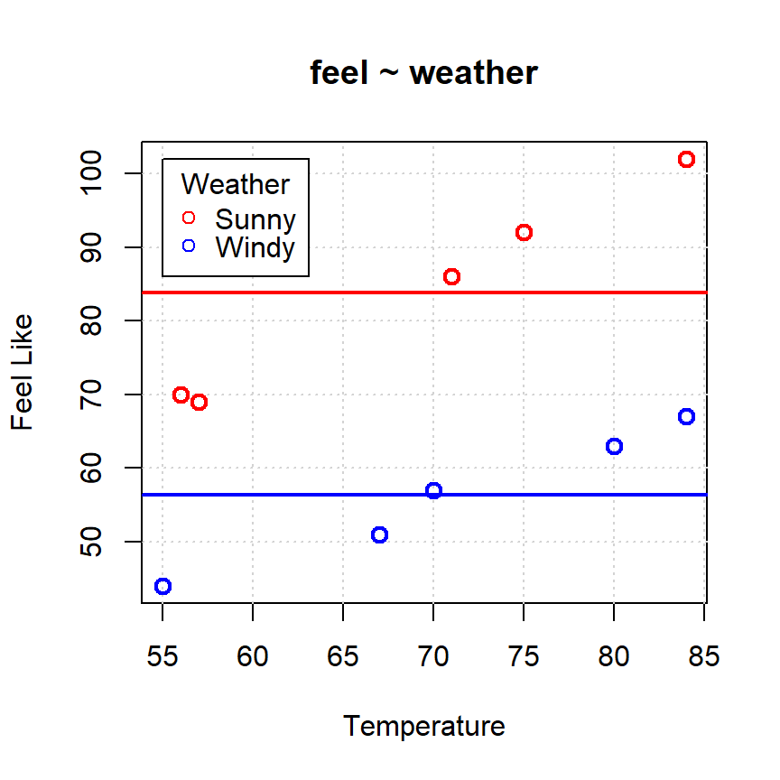

## 3.8 Interaction

- An **interaction** term is a kind of feature engineering in which two (or more) explanatory variables are multiplied together to form a new explanatory variable. This is more interesting when one explanatory variable is quantitative / continuous while another is categorical.
- In R’s formula, use the `x1:x2` notation to denote a **2nd order** / **two-way** interaction term between two explanatory variables `x1` and `x2`. Meanwhile, the **1st order** terms `x1` and `x2` are called the **main effects**.

```r
summary(lm(feel ~ temperature + weather + temperature:weather, data = data))
```

```
Call:
lm(formula = feel ~ temperature + weather + temperature:weather,
    data = data)

Residuals:
    Min      1Q  Median      3Q     Max
-2.0532 -0.5849  0.1807  0.5925  1.5562

Coefficients:
                         Estimate Std. Error t value Pr(>|t|)
(Intercept)               2.55440    3.80751   0.671  0.52726
temperature               1.18434    0.05483  21.598 6.43e-07 ***
weatherWindy             -2.89105    5.62791  -0.514  0.62583
temperature:weatherWindy -0.38748    0.07954  -4.871  0.00279 **
---
Signif. codes:  0 '***' 0.001 '**' 0.01 '*' 0.05 '.' 0.1 ' ' 1

Residual standard error: 1.317 on 6 degrees of freedom
Multiple R-squared:  0.9966,    Adjusted R-squared:  0.9948
F-statistic: 579.7 on 3 and 6 DF,  p-value: 8.878e-08
```

- The model equation is
  $$\begin{align}
  (\text{feel})
  &= 2.55 + 1.18\,(\text{temperature}) - 2.89
  \,\mathbf{1}_{\{\text{Windy}\}} - 0.39
  \,(\text{temperature})\,\mathbf{1}_{\{\text{Windy}\}}\\
  &=(2.55 - 2.89 \,\mathbf{1}_{\{\text{Windy}\}}) + (1.18 - 0.39
  \,\mathbf{1}_{\{\text{Windy}\}})\,(\text{temperature})\\
  &=\begin{cases}
  2.55 + 1.18\,(\text{temperature}) & \text{if Sunny}\\
  -0.34 + 0.80\,(\text{temperature}) & \text{if Windy}
  \end{cases}
  \end{align}$$

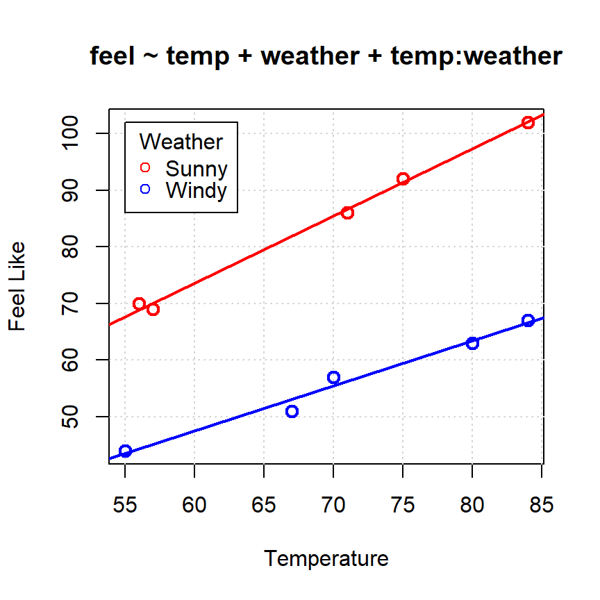

- This linear regression model is exactly the same as fitting two separate linear regression models to each group of the observed data.

```r
lm(feel ~ temperature, data = data, subset = weather == 'Sunny')
lm(feel ~ temperature, data = data, subset = weather == 'Windy')
```

```
Call:
lm(formula = feel ~ temperature, data = data, subset = weather ==
    "Sunny")

Coefficients:
(Intercept)  temperature
      2.554        1.184


Call:
lm(formula = feel ~ temperature, data = data, subset = weather ==
    "Windy")

Coefficients:
(Intercept)  temperature
    -0.3366       0.7969
```

- Without any interaction, the `temperature` explanatory variable affects the slope while the `weather` explanatory variable affects the intercept of the model separately. With `temperature:weather` interaction term, the overall effect is no longer simply the additive effect of each part. They “interact” in this sense.
- In the design matrix $X\in\mathbb{R}^{10\times 4}$, the last column $x_3 = x_1\times x_2$ is simply the product of the other two `temperature` and `weatherWindy` columns.

```r
(X <- model.matrix(feel ~ temperature + weather + temperature:weather, data = data))
```

```
   (Intercept) temperature weatherWindy temperature:weatherWindy
1            1          57            0                        0
2            1          75            0                        0
3            1          71            0                        0
4            1          56            0                        0
5            1          84            0                        0
6            1          84            1                       84
7            1          55            1                       55
8            1          80            1                       80
9            1          67            1                       67
10           1          70            1                       70
attr(,"assign")
[1] 0 1 2 3
attr(,"contrasts")
attr(,"contrasts")$weather
[1] "contr.treatment"
```

- In R, we can use the shorthand notation `x1 * x2` for `x1 + x2 + x1:x2`.

```r
lm(feel ~ temperature * weather, data = data)
```

```
Call:
lm(formula = feel ~ temperature * weather, data = data)

Coefficients:
             (Intercept)               temperature              weatherWindy
                  2.5544                    1.1843                   -2.8910
temperature:weatherWindy
                 -0.3875
```

- Another way to fit the same linear regression model is to not drop one level of the categorical variable. To do so, we use some R’s formula algebra to omit those terms that would cause multicollinearity. The model equation is
  $$\begin{align}
  (\text{feel})
  &= 2.55 \,\mathbf{1}_{\{\text{Sunny}\}} - 0.34
  \,\mathbf{1}_{\{\text{Windy}\}} + 1.18
  \,(\text{temperature})\,\mathbf{1}_{\{\text{Sunny}\}} + 0.80
  \,(\text{temperature})\,\mathbf{1}_{\{\text{Sunny}\}}\\
  &= \left(2.55 + 1.18
  \,(\text{temperature})\right)\,\mathbf{1}_{\{\text{Sunny}\}} +
  \left(-0.34 + 0.80
  \,(\text{temperature})\right)\,\mathbf{1}_{\{\text{Windy}\}}\\
  &=\begin{cases}
  2.55 + 1.18\,(\text{temperature}) & \text{if Sunny}\\
  -0.34 + 0.80\,(\text{temperature}) & \text{if Windy}
  \end{cases}
  \end{align}$$

```r
# feel ~ 1 + temperature + weather + temperature:weather
lm(feel ~ temperature * weather - 1 - temperature, data = data)
lm(feel ~ 0 + weather + temperature:weather, data = data) # No constant intercept
```

```
Call:
lm(formula = feel ~ temperature * weather - 1 - temperature,
    data = data)

Coefficients:
            weatherSunny              weatherWindy  temperature:weatherSunny
                  2.5544                   -0.3366                    1.1843
temperature:weatherWindy
                  0.7969


Call:
lm(formula = feel ~ 0 + weather + temperature:weather, data = data)

Coefficients:
            weatherSunny              weatherWindy  weatherSunny:temperature
                  2.5544                   -0.3366                    1.1843
weatherWindy:temperature
                  0.7969
```

- It is possible to have multi-way and higher-order interaction terms too. See `?formula`. For example:
  - `x1 * x2 * x3` represents `x1 + x2 + x3 + x1:x2 + x1:x3 + x2:x3 + x1:x2:x3` all lower-order interactions up to the highest-order all-way interaction term. (This is the reason why the `I()` notation is needed to distinguish this from `I(x1 * x2 * x3)`.)
  - `(x1 + x2 + x3) ^ 2` represents `x1 + x2 + x3 + x1:x2 + x1:x3 + x2:x3` up to 2nd-order interactions only.

# 4 Statistical Model

- A **statistical model** assumes the observed data are **realizations** of random variables from some unknown probability distribution.
- We usually assume the set of observed data $x_1,\dotsc,x_n$ is an **i.i.d. sample** from some population. It means the corresponding random variables $X_1,\dotsc,X_n$ are independent and identically distributed with the same probability distribution (denoted by its cumulative distribution function) $F$ which describes the overall population.

## 4.1 Bernoulli ${\small\text{Bern}(p)}$

- A random variable $X \sim \text{Bern}(p)$ with “mean” parameter $0<p<1$ only takes on either $0$ or $1$ value (its **domain** or **support**). It describes a binary outcome e.g. $1$ = success, $0$ = failure.
- *Example:* Let $A$ be an event that occurs randomly e.g. $A=``\text{rain tomorrow"}$. The binary indicator variable
  $$\textbf{1}_{\{\text{rain tomorrow}\}} = \textbf{1}_A =
  \begin{cases}
  1 & \text{if } A \text{ occurs}\\
  0 & \text{if } A \text{ does not occur}
  \end{cases} \sim \text{Bern}(p)$$
  is a Bernoulli random variable with parameter $p=P(A)$.

```r
# Simulate Bern(p) observations
p <- 0.3
rbinom(10, size = 1, prob = p) # size=1 since Bern(p) = Binom(n=1,p)
```

```
 [1] 1 0 0 1 0 1 0 0 0 0
```

- Probability mass function $p_X$ can be written in two equivalent ways:
  $$\begin{align}
  P(X=x) = p_X(x) &=
  \begin{cases}
  p & \text{if } x = 1\\
  1-p & \text{if } x = 0
  \end{cases}\\
  &= p^x(1-p)^{1-x}
  \end{align}$$
  The 2nd way is useful for writing the likelihood function and differentiate to compute maximum likelihood estimate MLE later.
- Mean $\mathbb{E}(X)$ and variance $\text{Var}(X)$ are
  $$\begin{align}
  \mathbb{E}(X) &= 1\times p + 0 \times (1-p) = p\\
  \text{Var}(X) &= \mathbb{E}(X-p)^2 =p(1-p)
  \end{align}$$
  Note $\text{Var}(X)\approx 0$ when $p\approx 0$ or $1$. Highest variance $\text{Var}(X) = 1/4$ when $p=0.5$ i.e. $X$ has most uncertainty.
- *Example:* For a binary indicator random variable $\textbf{1}_A$
  $$\mathbb{E}(\textbf{1}_A) = p = P(A)$$
- CDF $F_X$ is two-step with jumps of $1-p$ at $x=0$ and $p$ at $x=1$
- In practice, it is often used to represent the output of binary classification model such as [logistic regression](https://en.wikipedia.org/wiki/Logistic_regression).

## 4.2 Binomial ${\small\text{Binom}(n,p)}$

- A random variable $X \sim \text{Binom}(n,p)$ with fixed (not a parameter) $n$ number of trials and parameter $0<p<1$ takes on value within $\{0,\dotsc,n\}$. It describes the number of successes in $n$ independent Bernoulli trials e.g. number of heads in $n$ coin tosses.

```r
# Simulate Binom(n,p) observations
n <- 10
p <- 0.6
rbinom(20, size = n, prob = p)
```

```
 [1] 3 6 5 5 3 8 7 9 7 7 8 4 6 6 5 4 4 6 5 5
```

- Probability mass function $p_X$ is
  $$P(X=x) = p_X(x) = \binom{n}{x}p^x
  (1-p)^{n-x} = P(x\text{ successes in }n\text{ trials})$$
- “Binomial is a sum of Bernoulli” i.e. if $X_1,\dotsc,X_n \sim \text{Bern}(p)$ are independent, then
  $$X_1+\dotsb+X_n\sim\text{Binom}(n,p)$$
- By linearity of expectation and variance (for independent random variables),
  $$\begin{align}
  \mathbb{E}(X) &= \mathbb{E}(X_1)+\dotsb+\mathbb{E}(X_n)=np\\
  \text{Var}(X) &= \text{Var}(X_1)+\dotsb+\text{Var}(X_n)=np(1-p)
  \end{align}$$
- Probability mass function $p_X$ is unimodal and centered near its mean $\mathbb{E}(X) = np$.

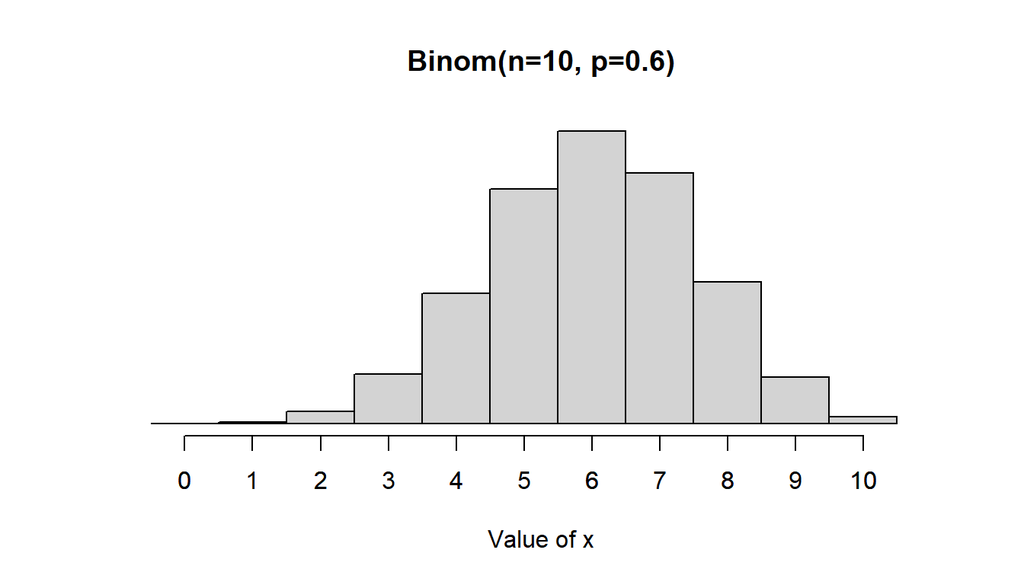

- In practice, it is often used in statistical hypothesis testing (also called A/B test in the industry) e.g. how many customers in a treatment group make purchases.

## 4.3 Uniform ${\small\text{Unif}(a,b)}$

- A random variable $X\sim\text{Unif}(a,b)$ with parameters $-\infty<a<b<\infty$ has support on the $[a,b]$ interval.

```r
# Simulate Unif(-1,2) observations
a <- -1
b <- 2
runif(5, min = a, max = b)
```

```
[1] 0.6816963 0.6983556 0.7439175 1.9898510 0.3372242
```

- Probability density function $f_X$ is
  $$f_X(x) =
  \begin{cases}
  1/(b-a) & \text{if } a\leq x \leq b\\
  0 & \text{otherwise }
  \end{cases}$$
- Mean value $\mathbb{E}(X)$ is the midpoint of the $[a,b]$ interval
  $$\mathbb{E}(X) = \frac{a+b}{2}$$

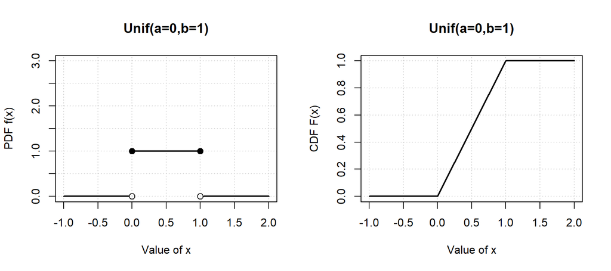

## 4.4 Univariate Gaussian / normal ${\small\mathcal{N}(\mu, \sigma^2)}$

- A **standard Gaussian** or **normal** random variable $Z\sim\mathcal{N}(0,1)$ has probability density function
  $$f_Z(z) =\phi(z) =
  \frac{1}{\sqrt{2\pi}}e^{-\frac{1}{2}z^2}$$
  with support on the entire real number line $\mathbb{R}=(-\infty,\infty)$. Its cumulative distribution function $F_Z(x)=\Phi(z)$ is an integral but does not have a simple closed-form formula.

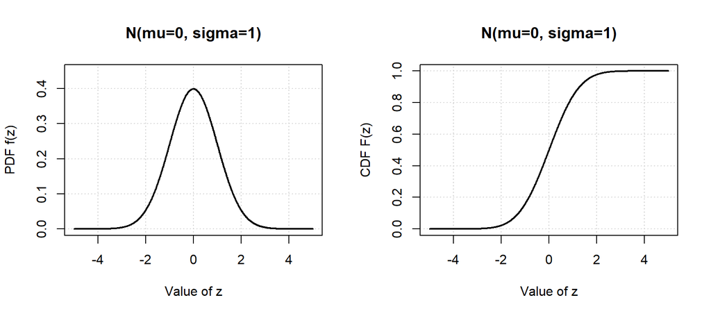

- Probability density function $\phi(z)$ is a unimodal **bell-shaped** curve. Since it is symmetric around $z=0$, the mean / median / mode are all equal.
  $$\mathbb{E}(Z) =
  0\quad\quad\text{Var}(Z) = 1 = \text{SD}(Z)$$
- In practice, the cumulative distribution function $\Phi(z)$ is sometimes used as a mathematical function to “squeeze” the real line $\mathbb{R}$ monotonically onto the unit interval $(0,1)$.
- Let $-\infty<\mu<\infty$ be the **location** parameter and $\sigma > 0$ be the **scale** parameter. By performing an **affine transformation** to first scale and then translate $Z$, we obtain a general normal random variable
  $$X = \mu + \sigma Z
  \sim\mathcal{N}(\mu, \sigma^2)$$
  with probability density function
  $$f_X(x) =
  \frac{1}{\sqrt{2\pi\sigma^2}}e^{-\frac{1}{2}\left(\frac{x -
  \mu}{\sigma}\right)^2}$$

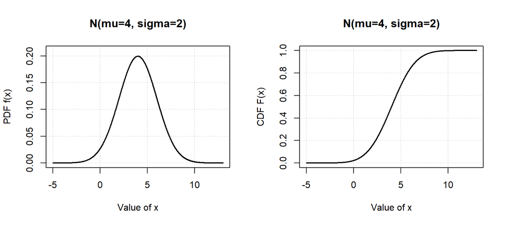

```r
# Simulate N(4,4) observations
mu <- 4
sigma <- 2
rnorm(5, mean = mu, sd = sigma)
```

```
[1] 2.015505 2.993980 3.951921 3.942039 4.895343
```

- By linearity of expectation and variance,
  $$\begin{align}
  \mathbb{E}(X) &= \mu + \sigma\mathbb{E}(Z) = \mu\\
  \text{Var}(X) &= \sigma^2 \text{Var}(Z) = \sigma^2\\
  \text{SD}(X) &=\sigma
  \end{align}$$
- Conversely, if $X\sim\mathcal{N}(\mu,\sigma^2)$, then we can reverse the transformation to obtain the standard normal
  $$Z =
  \frac{X-\mu}{\sigma}\sim\mathcal{N}(0,1)$$
- In general, for any random variable $X$, this kind of transformation
  $$Y=\frac{X - \mathbb{E}(X)}{\text{SD}(X)}$$
  is called **standardization** or **normalization**. The resulting random variable $Y$ always has $\mathbb{E}(Y)=0$ and $\text{Var}(Y) = \text{SD}(Y) = 1$.
- (Continuing with normal distribution.) Probability density function $f_X$ is centered at $x=\mu$ with **inflection points** at $x=\mu\pm\sigma$.
- **68% 95% 99.7% rule**: The probability of an observation (or area under the curve) falling within $\pm 1$ (or $\pm 2$ or $\pm 3$) $\sigma$ standard deviation(s) from the mean $\mu$ is approximately 68.3%, 95.5%, and 99.7% respectively.

[figure not shown]

  ([Source](https://commons.wikimedia.org/wiki/File:Standard_deviation_diagram_micro.svg))
- Probability density function $f_X$ has a **thin tail** since it decays very fast like $e^{-x^2}$. In practice, this means the chance of observing data that is “more than a few standard deviations away from the mean” is unlikely.
- A mathematical way to measure the tail heaviness of a probability distribution is **kurtosis**
  $$\text{Kurt}(X) =
  \frac{\mathbb{E}\left((X-\mu)^4\right)}{\left(\mathbb{E}(X-\mu)^2\right)^2}
  > 0$$
  Larger kurtosis value means heavier tail.
- A normal $\mathcal{N}(\mu,\sigma^2)$ distribution always has kurtosis $\text{Kurt}(X)=3$.
- Linear combination: If $X_1,\dotsc,X_n$ are independent $N(\mu_i,\sigma_i^2)$ random variables and $a_1,\dotsc,a_n$ are any constants, then
  $$a_1 X_1+\dotsb+a_n
  X_n\sim\mathcal{N}(a_1\mu_1+\dotsb+a_n\mu_n,\,a_1^2\sigma_1^2+\dotsb+a_n^2\sigma_n^2)$$
  Conversely, if $X\perp Y$ are independent and their sum $X+Y$ is normally distributed, then $X$ and $Y$ are also normally distributed (individually).
- The most important role of the normal distribution is due to the [central limit theorem](https://en.wikipedia.org/wiki/Central_limit_theorem) CLT.

## 4.5 Inference

- A parametric statistical model $F_\theta$ is indexed by the parameter $\theta$. The set $\Theta$ of all possible parameters of interest (or in consideration) is called the **parameter space**.
- **Statistical inference** is the task of using the observed data to:
  - Compute **point estimate** $\hat{\theta}$ of the unknown parameter $\theta$ (or some related quantity) within the parameter space $\Theta$
  - Construct **confidence interval** to describe the uncertainty of estimation
  - Perform **hypothesis testing** to assess the plausibility of the unknown parameter $\theta$ being equal to some hypothesized value $\theta_0\in\Theta$
- *Example:* Let $x_1,\dotsc,x_n$ be an i.i.d. sample from $\mathcal{N}(\mu,\sigma^2)$ distribution with unknown mean $\mu$ and variance $\sigma^2$ parameters. It might make sense to estimate $\mu$ by the **sample mean**
  $$\hat{\mu} = \bar{x}\equiv\frac{1}{n}\sum_{i=1}^n
  x_i$$
  and estimate $\sigma^2$ by the **(unadjusted) sample variance**
  $$\hat{\sigma}^2 = \frac{1}{n}\sum_{i=1}^n
  \left(x_i -\bar{x}\right)^2$$

```r
n <- 100 # Number of observed data
x <- rnorm(n, mean = 7, sd = 2) # N(7,4)

(x.bar <- mean(x))

mean((x - x.bar)^2)
```

```
[1] 6.734491
[1] 3.258627
```

- For given values of the observed data $x_1,\dotsc,x_n$, their sample mean $\bar{x}$ is an **estimate** of the unknown true mean parameter $\mu$. But if we view these observed data as a particular realized sample of the corresponding random variables $X_1,\dotsc,X_n$, then
  $$\hat{\theta}=\bar{X}\equiv\frac{1}{n}\sum_{i=1}^n
  X_i$$
  is also a random variable. This is called an **estimator**. It describes a recipe to estimate the unknown parameter $\theta$.

## 4.6 Biasedness

- One desirable property of an estimator $\hat{\theta}$ is to be **unbiased** i.e.
  $$\mathbb{E}_\theta(\hat{\theta}) =
  \theta\quad\text{for all }\theta\in\Theta$$
  Here $\mathbb{E}_\theta$ means the expected value when the true parameter is $\theta$. Equality needs to hold no matter what the true parameter $\theta\in\Theta$ is.
- *Example:* The i.i.d. sample mean is always an unbiased estimator of the unknown true mean parameter. Why? By linearity of expectation, if $X_1,\dotsc,X_n$ is an i.i.d. sample from probability distribution $F$ with mean $\mathbb{E}(X) = \mu$, then
  $$\mathbb{E}_\mu(\bar{X}) =
  \mathbb{E}_\mu\left(\frac{1}{n}\sum_{i=1}^n X_i\right) = \mu$$
  no matter what $\mu$ is.

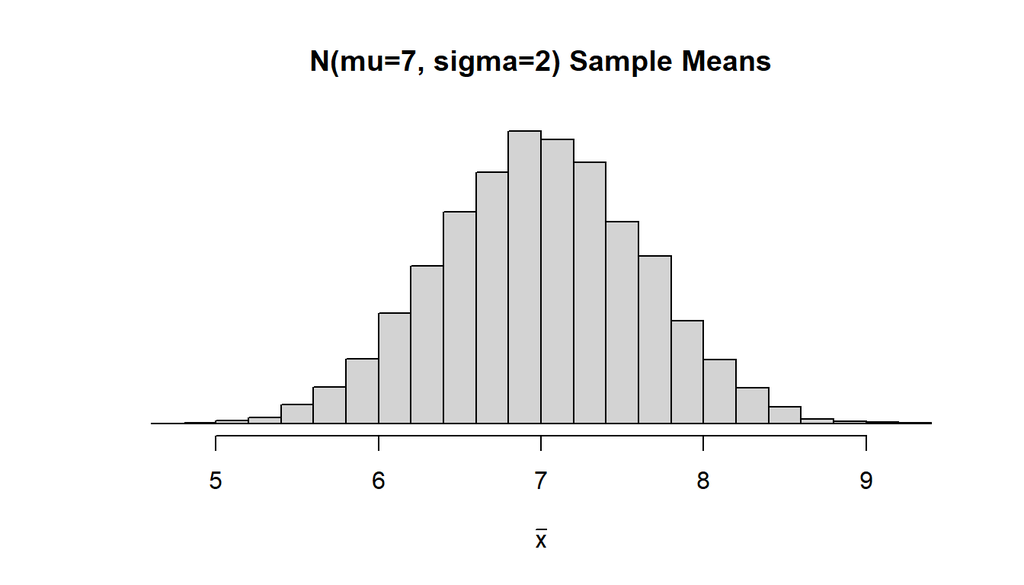

```r
set.seed(1)

num.of.estimate <- 10000
sample.means <- numeric(num.of.estimate)

for (i in seq_len(num.of.estimate)) {
  n <- 10
  x <- rnorm(n, mean = 7, sd = 2) # N(7,4) with mu = 7
  sample.means[i] <- mean(x) # Sample mean estimator
}

hist(sample.means,
     breaks=25,
     xlab=expression(bar(x)),
     yaxt='n', ylab='',
     main='N(mu=7, sigma=2) Sample Means')
```

```r
mean(sample.means) # E(sample mean estimator) = mu
```

```
[1] 6.995512
```

- *Broken Clock Example:* Suppose we propose to use a (constant) estimator $\hat{p}=0.4$ for the $\text{Bern}(p)$ distribution i.e. no matter what the unknown true parameter $0<p<1$ is or what the observed sample data $x_1,\dotsc,x_n$ are, we just say “our estimate of $p$ is always 0.4”. This constant estimator is correct only when $p=0.4$. Otherwise, it would be either an under-estimate or over-estimate in other cases when $p\neq 0.4$. So it is not unbiased for all values of $p$ in the parameter space $\Theta=(0,1)$.
- In general, the **bias** of an estimator $\hat{\theta}$ is
  $$\text{Bias}(\hat{\theta}) =
  \mathbb{E}_\theta(\hat{\theta}) - \theta$$
- *Example:* The (unadjusted) sample variance is always a biased estimator for the unknown true variance $\sigma^2$.
  $$\mathbb{E}(\hat{\sigma}^2)=\mathbb{E}\left(\frac{1}{n}\sum_{i=1}^n
  \left(X_i -\bar{X}\right)^2\right)=\dotso=\frac{n-1}{n}\sigma^2 <
  \sigma^2$$
  In other words, the (unadjusted) sample variance tends to underestimate the true variance. Intuitively, since the $n$ summands
  $$\sum_{i=1}^n (X_i-\bar{X}) = \left(\sum_{i-1}^n
  X_i\right) - n\bar{X} = 0$$
  i.e. they must sum to 0. The last summand is completely determined by the first $n-1$ terms. There are only $n-1$ “independent things” or **degrees of freedom**. (In linear algebra, it is a $d$-dimensional vector in a $(d-1)$-dimensional subspace.) So it makes sense to divide by $n-1$ instead of $n$.
- *Example:* The (adjusted) **sample variance**
  $$\hat{\sigma}^2=\frac{1}{n-1}\sum_{i=1}^n
  \left(x_i -\bar{x}\right)^2$$
  is always an unbiased biased estimator for the unknown true variance $\sigma^2$. In other words,
  $$\mathbb{E}(\hat{\sigma}^2)=\mathbb{E}\left(\frac{1}{n-1}\sum_{i=1}^n
  \left(X_i -\bar{X}\right)^2\right)= \sigma^2$$

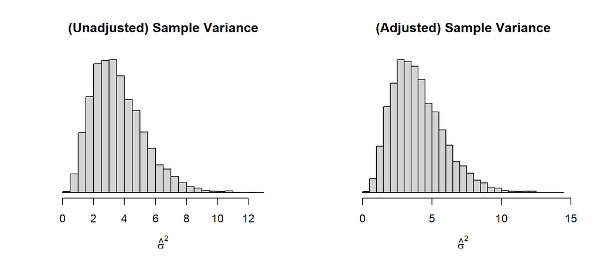

```r
num.of.estimate <- 10000
unadjusted.sample.var <- numeric(num.of.estimate)
sample.var <- numeric(num.of.estimate)

for (i in seq_len(num.of.estimate)) {
  n <- 10
  x <- rnorm(n, mean = 7, sd = 2) # N(7,4) with mu = 7
  unadjusted.sample.var[i] <- mean((x - mean(x))^2) # Unadjusted sample variance
  sample.var[i] <- sum((x - mean(x))^2) / (n - 1) # Adjusted sample variance
}

par(mfrow=c(1,2))
hist(unadjusted.sample.var,
     breaks=20,
     xlab=expression(hat(sigma)^2),
     yaxt='n', ylab='',
     main='(Unadjusted) Sample Variance')
hist(sample.var,
     breaks=20,
     xlab=expression(hat(sigma)^2),
     yaxt='n', ylab='',
     main='(Adjusted) Sample Variance')
```

```r
mean(unadjusted.sample.var)
mean(sample.var)
```

```
[1] 3.613107
[1] 4.014564
```

- In practice, this concept of biasedness also appears in machine learning as the [bias-variance tradeoff](https://en.wikipedia.org/wiki/Bias%E2%80%93variance_tradeoff). It says that, while it is a good characteristic for an estimator to be unbiased, sometimes we can trade a bit of increase in biasedness for much reduced variance and hence better overall result.

## 4.7 Likelihood Principle

- Let $x_1,\dotsc,x_n$ be a set of $n$ observed i.i.d. sample data points from a parametric statistical model $F_\theta$ with unknown true parameter $\theta$. We would like to have a principled approach to perform parameter estimation and statistical inference. This is in contrast to ad-hoc approach e.g. “if $\theta$ is the true mean, then let’s estimate it using something that looks alike e.g. sample mean” without knowing why this might (or might not) be the ideal thing to do.
- The **likelihood function** is
  $$L(\theta) = P_\theta(X_1=x_1,\dotsc,X_n=x_n) =
  P_\theta(X_1=x_1)\times\dotsb\times P_\theta(X_n=x_n) = \prod_{i=1}^n
  P_\theta(X_i=x_i)$$
  In other words, it is the probability (or likeliness) of observing the given observed data under the model parameter $\theta$. We usually view this quantity as a function of $\theta$ with fixed data.
- The **log-likelihood function** is
  $$l(\theta) = \log L(\theta) = \log \prod_{i=1}^n
  P_\theta(X_i=x_i) = \sum_{i=1}^n \log P_\theta(X_i=x_i)$$
- Why take logarithm? (Starting from the more obvious to the deepest.)
  1. Maximizing $L(\theta)$ or $l(\theta)$ yield the same optimum $\theta^*$ since $\log(x)$ is a monotonic function
  2. It is easier to take derivative of a sum than a product (in case we use first-order condition to compute optimum)
  3. $\log P_\theta(x)$ is often simpler when the density function $P_\theta(x)$ has an exponential form e.g. $\mathcal{N}(\mu,\sigma^2)$
  4. Numerical computation of a product of many small numbers $\approx 0$ results in [arithmetic underflow](https://en.wikipedia.org/wiki/Arithmetic_underflow)
  5. The sum of “things” has a deep connection with the $\mathcal{X}_k^2$ distribution and related hypothesis tests.
- The **maximum likelihood principle** says that the best estimate of the unknown true parameter $\theta$ is the one that makes the observed data the most likely to occur
  $$\theta^*_\text{MLE} =
  \mathop{\mathrm{arg\,max}}_{\theta\in\Theta} L(\theta)$$
  This optimal choice $\theta^*_\text{MLE}$ is the **maximum likelihood estimate MLE**.
- *Example:* For $\text{Bern}(p)$ distribution, the likelihood and log-likelihood functions are
  $$L(p)=\prod_{i=1}^n p^{x_i} (1-p)^{1 - x_i}$$
  $$l(p) = \log L(p) = \sum_{i=1}^n x_i \log(p) +
  (1-x_i)\log(1-p) = \left(\sum_{i=1}^n x_i\right)\log(p) + \left(n -
  \sum_{i=1}^n x_i\right)\log(1-p)$$
  By differentiating $l(p)$ and solving the first-order condition $l'(p)=0$, the maximum likelihood estimate MLE is
  $$p^*_\text{MLE}=
  \mathop{\mathrm{arg\,max}}_{p\in(0,1)} l(p) = \frac{1}{n}\sum_{i=1}^n
  x_i = \bar{x}$$

```r
x <- c(0, 1, 1, 0, 0, 1, 0, 0, 0, 1)

L <- function(p) {
  return(prod(p^x * (1-p)^(1-x)))
}

l <- function(p) {
  n <- length(x)
  return(sum(x) * log(p) + (n - sum(x)) * log(1-p))
}
```

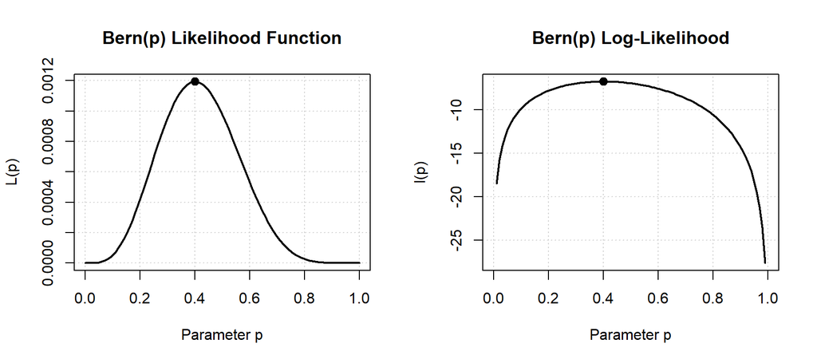

- *Example:* For $\mathcal{N}(\mu,\sigma^2)$ distribution, the likelihood and log-likelihood functions are
  $$L(\mu,\sigma^2) =\prod_{i=1}^n
  f_{\mu,\sigma^2}(x_i) = \prod_{i=1}^n
  \frac{1}{\sqrt{2\pi\sigma^2}}e^{-\frac{1}{2}\left(\frac{x_i -
  \mu}{\sigma}\right)^2}$$
  $$l(\mu,\sigma^2) = \log L(\mu,\sigma^2) =
  \sum_{i=1}^n \log\left(\frac{1}{\sqrt{2\pi\sigma^2}}\right)
  -\frac{1}{2}\left(\frac{x_i - \mu}{\sigma}\right)^2 =
  -\frac{n}{2}\log(2\pi\sigma^2) - \frac{1}{2\sigma^2}\sum_{i=1}^n (x_i -
  \mu)^2$$
  By differentiating $l(\mu,\sigma^2)$ over both variables $\mu$ and $\sigma^2$, and solving the two first-order conditions, the maximum likelihood estimates MLEs are
  $$\mu^*_\text{MLE}= \frac{1}{n}\sum_{i=1}^n x_i =
  \bar{x}$$
  $$\sigma^{2}_\text{MLE}=
  \frac{1}{n}\sum_{i=1}^n (x_i-\bar{x})^2 = \hat{\sigma}^2$$
  In other words, they are the sample mean and (unadjusted) sample variance.
- Is the maximum likelihood principle (and hence the maximum likelihood estimate MLE) always the most ideal answer? Not necessarily.
- *Example:* For $\mathcal{N}(\mu,\sigma^2)$ distribution, the MLE $\sigma^{2}_\text{MLE}$ derived directly based on the likelihood function is the (unadjusted) sample variance. It is biased.
- *Example:* For $\text{Bern}(p)$ distribution, if all $x_1 =\dotsb = x_n = 0$ i.e. all $n$ observed coin tosses are tails, then the MLE would be
  $$p^*_\text{MLE} = \bar{x} =
  0$$
  In other words, it estimates the coin is most likely to have no chance of head. This is absurd.
- In practice, the [Bayesian statistical framework](https://en.wikipedia.org/wiki/Bayesian_inference) is one way to address this kind of issue.

# 5 Linear Regression Part 2

## 5.1 Statistical Assumption

- Until now, we have framed the linear regression model as a mathematical optimization problem to find the optimal parameters $\beta_0^*,\dotsc,\beta_d^*$ which minimize the mean squared error MSE
  $$\min_{\beta_0,\dotsc,\beta_d}\,\underbrace{\frac{1}{n}\sum_{i=1}^n
  \big(y_i - (\beta_0 + \beta_1 x_{i1}+\dotsb+\beta_d
  x_{id})\big)^2}_\text{MSE}$$
  Now let us reframe linear regression as a parametric statistical model along with its statistical inference perspective i.e. point estimate, confidence interval, and hypothesis testing.
- Let $(\vec{x}_1,y_1),\dotsc,(\vec{x}_n,y_n)$ be $n$ pairs of observed data points with $d$-dimensional explanatory variable $\vec{x}_i = (x_{i1},\dotsc,x_{id})\in\mathbb{R}^d$. The statistical model assumption of linear regression is
  $$Y_i =
  \beta_0 + \beta_1 x_{i1} + \dotsb + \beta_d x_{id} +
  \epsilon_i\quad\text{where}\quad\epsilon_i\overset{\text{i.i.d.}}{\sim}\mathcal{N}(0,\sigma^2)$$
  Equivalently, we have
  $$Y_i\overset{\text{indep}}{\sim}\mathcal{N}(\beta_0
  + \beta_1 x_{i1} + \dotsb + \beta_d x_{id},\sigma^2)\quad\text{for each
  }i=1,\dotsc,n$$
  In matrix form, it is a $n$-dimensional multivariate normal distribution
  $$\vec{Y}=\pmatrix{Y_1\\
  \vdots\\ Y_n}\sim\mathcal{N}_n(X \vec{\beta}, \sigma^2 I_n)$$
  with mean vector and covariance matrix
  $$\mathbb{E}(\vec{Y}) = X \vec{\beta} =
  \underbrace{\pmatrix{
  1 & x_{11} & \dots & x_{1d}\\
  \vdots & \vdots & \ddots & \vdots\\
  1 & x_{n1} & \dots & x_{nd}}}_\text{design
  matrix}\times\pmatrix{\beta_0\\ \vdots\\ \beta_d}\in\mathbb{R}^n
  \quad\quad\quad
  \text{Cov}(\vec{Y}) = \sigma^2 I_n = \underbrace{\pmatrix{
  \sigma^2 & \dots & 0\\
  \vdots & \ddots & \vdots\\
  0 & \dots & \sigma^2}}_\text{diagonal
  matrix}\in\mathbb{R}^{n\times n}$$
  This says:
  1. **Deterministic explanatory variable:** Explanatory variables $\vec{x}_i$ is fixed / deterministic / not a random variable in this statistical model.
  2. **Random response variable:** Response variable $Y_i$ is viewed as a random variable because the noise / error term $\epsilon_i$ is a random variable. Each observed response value $y_i$ is a realization of its random variable $Y_i$.
  3. **Normally distributed:** Since the amount of random error $\epsilon_i$ is normally distributed, so is $Y_i$. (Note this does not imply a histogram of the observed response values $y_1,\dotsc,y_n$ together would have a bell-shaped curve because each $Y_i$ has a different expectation $\mathbb{E}(Y_i)$.)
  4. **Linear:** There is a linear relationship between the expected response $\mathbb{E}(Y_i)$ and the explanatory variable $\vec{x}_i$.
     $$\mathbb{E}(Y_i) = \beta_0 + \beta_1 x_{i1} +
     \dotsb + \beta_d x_{id}$$
     For each $i^\text{th}$ observed data point, since $\vec{x}_i$ can be different, so could $\mathbb{E}(Y_i)$. The commonalty across the $n$ data points is the form of the linear equation along with the $\beta_0,\dotsc,\beta_d$ parameters.
  5. **Constant variance:** The random errors $\epsilon_i$’s have constant variance across all observed data points.
     $$\text{Var}(Y_i) = \text{Var}(\epsilon_i) =
     \sigma^2\quad\text{for each }i=1,\dotsc,n$$
  6. **Independence:** Since the random errors $\epsilon_i$’s are independent random variables, the response random variables $Y_1,\dotsc,Y_n$ are also independent too.
- By reframing as a statistical model, what do we gain beyond our previous focus on just MSE optimization?
  - **Model selection:** It provides a principled way to perform explanatory variable / model selection based on statistical hypothesis testing e.g. $H_0: \beta_j=0$ for usefulness of $x_j$.
  - **Confidence interval for prediction:** For an unseen value of explanatory variable $\vec{x}$, besides a point estimate $\hat{y}$ of predicted value, we can construct $(1-\alpha)\%$ confidence interval in the form $\hat{y}\pm t_{1-\alpha/2}\, (\text{s.e.})$.

## 5.2 Chi-squared ${\small \mathcal{X}^2_k}$

- A chi-squared random variable $X\sim\mathcal{X}_k^2$ with **degrees of freedom** parameter $k\in\mathbb{N}$ is a sum of $k$ squared independent standard normal random variables i.e.
  $$X = Z_1^2 + \dotsb +
  Z_k^2$$
  with $Z_1,\dotsc,Z_k\sim\mathcal{N}(0,1)$.
- It is always non-negative $X\geq 0$ i.e. has support on the non-negative real number line $[0,\infty)$.
- Probability density function $f_X$ is
  $$f_X(x) =
  \frac{x^{k/2-1}e^{-x/2}}{2^{k/2}\Gamma(k/2)}\quad\text{for
  }x>0$$
  where $\Gamma(k/2)$ is the complicated [gamma function](https://en.wikipedia.org/wiki/Gamma_function). Its cumulative distribution function $F_X$ is an integral but does not have a simple closed-form formula.

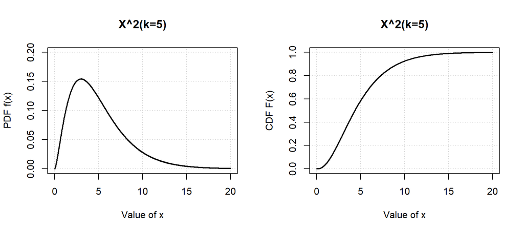

```r
# Simulate X^2(5) observations
k <- 5
rchisq(5, df = k)
```

```
[1] 3.391515 3.884121 6.998860 5.034811 6.481215
```

- Probability density function $f_X$ is right-skewed and unimodal with mode at $x=k-2$ when $k\geq 2$.
- By linearity of expectation and variance,
  $$\begin{align}
  \mathbb{E}(X) &= \mathbb{E}(Z_1^2)+\dotsb+\mathbb{E}(Z_k^2)= k\\
  \text{Var}(X) &= \text{Var}(Z_1^2)+\dotsb+\text{Var}(Z_k^2)= 2k
  \end{align}$$
- In practice, chi-squared distribution is mostly used in statistical hypothesis testing e.g. **chi-squared test** of independence for contingency table, goodness-of-fit test of observed data against some probability distribution, or likelihood ratio test LRT to select between two nested statistical models later.

## 5.3 Estimation of ${\small \vec{\beta}}$ and ${\small \sigma^2}$

- Based on the statistical assumption of linear regression model, the likelihood function is
  $$\begin{align}
  L(\beta_0,\dotsc,\beta_d,\sigma^2)
  &= P\left(Y_1=y_1,\dotsc,Y_n=y_n \right)
  = \prod_{i=1}^n P(Y_i = y_i)\\
  &= \prod_{i=1}^n \frac{1}{\sqrt{2\pi\sigma^2}}
  e^{-\frac{1}{2\sigma^2}\left( y_i - (\beta_0 + \beta_1 x_{i1} + \dotsb +
  \beta_d x_{id})\right)^2}\\
  &= (2\pi\sigma^2)^{-n/2}\,e^{-\frac{1}{2\sigma^2}\sum_{i=1}^n \left(
  y_i - (\beta_0 + \beta_1 x_{i1} + \dotsb + \beta_d x_{id})\right)^2}
  \end{align}$$
  The log-likelihood function is
  $$\begin{align}
  l(\beta_0,\dotsc,\beta_d,\sigma^2)
  &= \log L(\beta_0,\dotsc,\beta_d,\sigma^2)\\
  &= -\frac{n}{2}\log\left(2\pi\sigma^2\right)
  -\frac{1}{2\sigma^2}\sum_{i=1}^n \left( y_i - (\beta_0 + \beta_1 x_{i1}
  + \dotsb + \beta_d x_{id})\right)^2
  \end{align}$$
- By the likelihood principle, to maximize the likelihood function $L$ with respect to $\vec{\beta}$, it suffices to maximize the $2^\text{nd}$ term above, which is equivalent to minimizing the MSE. Therefore, the maximum likelihood estimate MLE for $\vec{\beta}$ is
  $$\vec{\beta}_\text{MLE}^* =
  \vec{\beta}_\text{LS}^* = (X^T X)^{-1} X^T \vec{y}$$
  is exactly the same as the optimal parameters $\vec{\beta}_\text{LS}^*$ via least squares previously.
- Later, we will perform statistical inference on the model parameter $\vec{\beta}$. To do so, we need to know the reference probability distribution of the estimator $\vec{\beta}_\text{MLE}^*$. Since the response vector $\vec{Y}\sim\mathcal{N}_n(X \vec{\beta}, \sigma^2 I_n)$ is multivariate normally distributed and $\vec{\beta}_\text{MLE}^*= (X^T X)^{-1} X^T \vec{Y}$ is a matrix multiplication (a kind of affine transformation) of $\vec{Y}$, it is also multivariate normally distributed. Now the mean vector and covariance matrix of $\vec{\beta}_\text{MLE}^*$ are
  $$\mathbb{E}(\vec{\beta}_\text{MLE}^*)= (X^T
  X)^{-1} X^T\,\mathbb{E}(\vec{Y}) = (X^T X)^{-1} X^T X \vec{\beta} =
  \vec{\beta}\in\mathbb{R}^d$$
  $$\text{Var}(\vec{\beta}_\text{MLE}^*) = (X^T
  X)^{-1} X^T\,\text{Var}(\vec{Y})\,X (X^T X)^{-T} = \sigma^2 (X^T
  X)^{-1}\in\mathbb{R}^{d\times d}$$
  Therefore,
  $$\vec{\beta}_\text{MLE}^*\sim\mathcal{N}_d(\vec{\beta},\,\sigma^2
  (X^T X)^{-1})$$
  In particular, $\vec{\beta}_\text{MLE}^*$ is an unbiased estimator for $\vec{\beta}$.
- The maximum likelihood estimate MLE for $\sigma^2$ is simply the (unadjusted) sample variance of the residuals, which is same as the mean squared error MSE i.e.
  $$\hat{\sigma}_\text{MLE}^2 =
  \frac{1}{n}\sum_{i=1}^n \big(\underbrace{y_i - \hat{y}_i}_{\text{error }
  e_i}\big)^2 = \frac{SS_\text{error}}{n} = \text{MSE}$$
- However, $\hat{\sigma}_\text{MLE}^2$ is not an unbiased estimator for $\sigma^2$. To see this, let us consider the simplest linear regression model with only the intercept term i.e.
  $$Y_i = \beta_0 +
  \epsilon_i\quad\text{where}\quad\epsilon_i\overset{\text{i.i.d.}}{\sim}\mathcal{N}(0,\sigma^2)$$
  It is equivalent to the statistical model
  $$Y_i\overset{\text{i.i.d.}}{\sim}\mathcal{N}(\beta_0,
  \sigma^2)$$
  which estimates the mean and variance parameters of a normal distribution based on observed data. We know an unbiased estimator for $\sigma^2$ requires the $n-1$ adjustment i.e.
  $$\hat{\sigma}^2=\frac{1}{n-1}\sum_{i=1}^n (y_i -
  \bar{y}_n)^2$$
- Back to multiple linear regression, let $p=1+d=\text{dim}(\vec{\beta})$ be the total number of intercept and slope parameters in the model. This is called the **model degrees of freedom**. (Note $p$ does not count the $\sigma^2$ parameter of the error term.) Now using the fact that
  $$\frac{SS_\text{error}}{\sigma^2} = \sum_{i=1}^n
  \left(\frac{y_i - \hat{y}_i}{\sigma}\right)^2
  \sim\mathcal{X}^2_{n-p}$$
  has a chi-squared distribution with $n-p$ degrees of freedom, we have $\mathbb{E}(SS_\text{error}/\sigma^2) = n-p$. Rewriting it yields
  $$\mathbb{E}\left(\frac{SS_\text{error}}{n-p}\right)
  = \sigma^2$$
  This motivates us to consider the following (adjusted) unbiased estimator for $\sigma^2$:
  $$\hat{\sigma}^2 = \frac{SS_\text{error}}{n-p} =
  \frac{1}{n-p}\sum_{i=1}^n (y_i - \hat{y}_i)^2$$
  The quantity $n-p$ is called the **residual degrees of freedom**. (This generalizes the above (adjusted) sample variance estimator beyond $p=1$.)

```r
x <- c(0.4, 0.8, 1.2, 1.7, 2.1)
y <- c(2, 5, 4.3, 4.2, 8)
model <- lm(y ~ x)

# Compute unscaled covariance matrix (X^T X)^{-1}
X <- model.matrix(y ~ x)
solve(t(X) %*% X)
summary(model)$cov.unscaled
```

```
            (Intercept)          x
(Intercept)   1.0302376 -0.6695464
x            -0.6695464  0.5399568
            (Intercept)          x
(Intercept)   1.0302376 -0.6695464
x            -0.6695464  0.5399568
```

```r
# Compute model degrees of freedom p
model$qr$rank
summary(model)$df[1]
```

```
[1] 2
[1] 2
```

```r
# Compute residual degrees of freedom n - p
df.residual(model)
model$df.residual
summary(model)$df[2]
length(y) - model$qr$rank
```

```
[1] 3
[1] 3
[1] 3
[1] 3
```

```r
# Compute adjusted unbiased estimated sigma
summary(model) # Residual standard error
summary(model)$sigma
sqrt(deviance(model) / df.residual(model)) # sqrt(SSE / (n - p))
```

```
Call:
lm(formula = y ~ x)

Residuals:
      1       2       3       4       5
-0.5410  1.4309 -0.2972 -1.6823  1.0896

Coefficients:
            Estimate Std. Error t value Pr(>|t|)
(Intercept)    1.513      1.488   1.017   0.3841
x              2.570      1.077   2.386   0.0971 .
---
Signif. codes:  0 '***' 0.001 '**' 0.01 '*' 0.05 '.' 0.1 ' ' 1

Residual standard error: 1.466 on 3 degrees of freedom
Multiple R-squared:  0.6549,    Adjusted R-squared:  0.5399
F-statistic: 5.694 on 1 and 3 DF,  p-value: 0.09707

[1] 1.465819
[1] 1.465819
```

## 5.4 Hypothesis Testing

- In statistical hypothesis testing, we have two competing hypotheses: the **null hypothesis** $H_0$ and the **alternative hypothesis** $H_1$ about the unknown true parameter(s) of our statistical model. Based on some observed data points, we would like to decide if the evidence supports $H_0$ or $H_1$.
- *Example:* To determine if a coin is fair or not, we toss the coin $n$ times and observe $x_1,\dotsc,x_n\in\{\text{head}, \text{tail}\}$. Our two hypotheses could be
  $$\begin{align}
  H_0:&\text{ Coin is fair i.e. } P(\text{head})=0.5\\
  H_1:&\text{ Coin is unfair i.e. } P(\text{head})\neq 0.5
  \end{align}$$
  In this case, $H_0$ is a **simple / point hypothesis** since it consists of only one possible value $p=0.5$ of the model parameter. On the other hand, $H_1$ is a **composite hypothesis** which consists of many possible values of the model parameter i.e. all $p\neq 0.5$.
- If our observed evidence supports $H_0$ and it turns out $H_0$ is actually true, then we are correct. Similarly for $H_1$. Otherwise, we make a mistake.
  - **Type I error**: Reject $H_0$ (or accept $H_1$) when $H_0$ is true
  - **Type II error**: Retain / fail to reject $H_0$ when $H_1$ is true
- In practice, the null hypothesis $H_0$ typically represents an existing view / conventional belief / baseline / no effect e.g. a new medicine is not useful. The alternative hypothesis $H_1$ typically represents a challenge perspective / new theory / impactful treatment e.g. a new medicine improves health. In this case, a type I error is usually considered worse than a type II error.
- To conduct a hypothesis test:
  1. Summarize the observed evidence into one number called a **test statistic**. In general, a **statistic** is a quantity derived from the observed data.
  2. This test statistic is viewed as an observed value of a random variable. It has a reference probability distribution.
  3. Compute **p-value** of this test statistic using its reference probability distribution under the assumption that the null hypothesis $H_0$ is true.
     $$\text{p-value} = P_{H_0}(\text{such or more
     extreme outcome than our observed evidence})$$
  4. This p-value represents the level of “surprise”. If p-value is small $\approx 0$, then our observed test statistic evidence is very extreme so it is unlikely to occur under $H_0$. This suggests that $H_0$ might be false.
- Most common misinterpretation of p-value:
  $$\text{p-value} \neq P(H_0\text{ is
  true})$$
  The null hypothesis $H_0$ is either true or false. It is unknown but not a random event. So p-value is not the probability of such.

## 5.5 Student’s ${\small t}$ ${\small t_\nu}$

- A Student’s $t$ random variable $X\sim t_\nu$ with **normality parameter** or **degrees of freedom** parameter $\nu> 0$ has probability density function
  $$f_X(x) =
  \frac{1}{\sqrt{\nu}B(1/2,\nu/2)}\left(1 + \frac{t^2}{\nu}\right)^{-(\nu
  + 1)/2}$$
  Here $B(1/2,\nu/2)$ is the complicated [Beta function](https://en.wikipedia.org/wiki/Beta_function) constant just to make the area under the probability density function $f_X$ curve equals to $1$. Its cumulative distribution function $F_X(x)$ is an integral but does not have a simple closed-form formula.

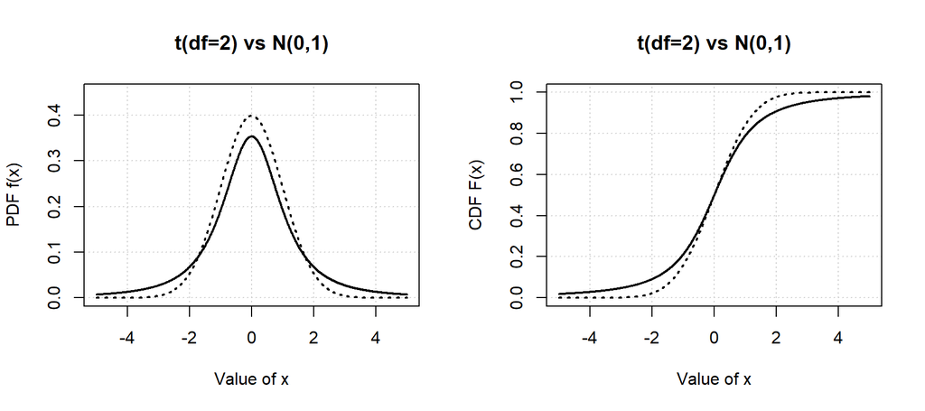

```r
# Simulate t(2) observations
nu <- 2
rt(5, df = nu)
```

```
[1]  0.4601457 -0.9656381  0.6731015  0.6987576 -0.1030360
```

- Probability density function $f_X$ is also a unimodal **bell-shaped** curve. Since it is symmetric around $x=0$, the mean / median / mode are all equal.
  $$\mathbb{E}(X) =
  0\quad\quad\text{Var}(X) =
  \begin{cases}
  \frac{\nu}{\nu - 2} & \text{if } \nu>2\\
  \infty & \text{otherwise }
  \end{cases}$$
- It is a **fat-tailed** distribution (relative to the thin tail of the normal distribution) with kurtosis
  $$\text{Kurt}(X) =
  \begin{cases}
  3 + \frac{6}{\nu - 4} & \text{if } \nu>4\\
  \infty & \text{otherwise }
  \end{cases}$$
  which is greater than $\text{Kurt}(\mathcal{N}(\mu,\sigma^2)) =3$. Smaller $\nu$ value yields heavier tail.
- In general, a probability distribution with high kurtosis and fat tail means it is not a **rare event** to observe sample data with large (positive or negative) magnitude.
- For $\nu\leq 2$, large positive and negative data are frequent enough that the Student’s $t$ distribution has infinite variance $\text{Var}(X)=\infty$.
- In practice, the Student’s $t$ distribution is often used in robust regression when outliers are more frequent. For example, in financial markets, large profits and losses are more frequent than would be described by a normal distribution.
- Student’s $t$ distribution plays an important role in one-sample and two-sample mean comparison hypothesis testing and confidence interval construction later.
- As $\nu\rightarrow\infty$, the Student’s $t$ distribution converges to the standard normal distribution
  $$t_\nu\overset{d}{\approx}\mathcal{N}(0,1)\quad\text{for
  large }\nu$$

## 5.6 F-distribution ${\small F_{d_1,d_2}}$

- An F-distributed random variable $X\sim F_{d_1,d_2}$ with degree of freedom parameters $d_1, d_2\in\mathbb{N}$ is a ratio of two independent $\mathcal{X}^2$ chi-squared random variables i.e.
  $$X =
  \frac{C_1/d_1}{C_2/d_2}$$
  with $C_1\sim\mathcal{X}^2_{d_1}$ and $C_2\sim\mathcal{X}^2_{d_2}$.
- It is always positive $X > 0$ i.e. has support on the positive real number line $(0,\infty)$.
- Probability density function $f_X$ is
  $$f_X(x) =
  \frac{1}{\text{B}\left(\frac{d_1}{2},\frac{d_2}{2}\right)}\left(\frac{d_1}{d_2}\right)^{d_1/2}x^{d_1/2
  - 1}\left(1 + \frac{d_1}{d_2}x\right)^{-(d_1+d_2)/2}\quad\text{for
  }x>0$$
  where $\text{B}\left(\frac{d_1}{2},\frac{d_2}{2}\right)$ is the complicated [beta function](https://en.wikipedia.org/wiki/Beta_function). Its cumulative distribution function $F_X$ is an integral but does not have a simple closed-form formula.

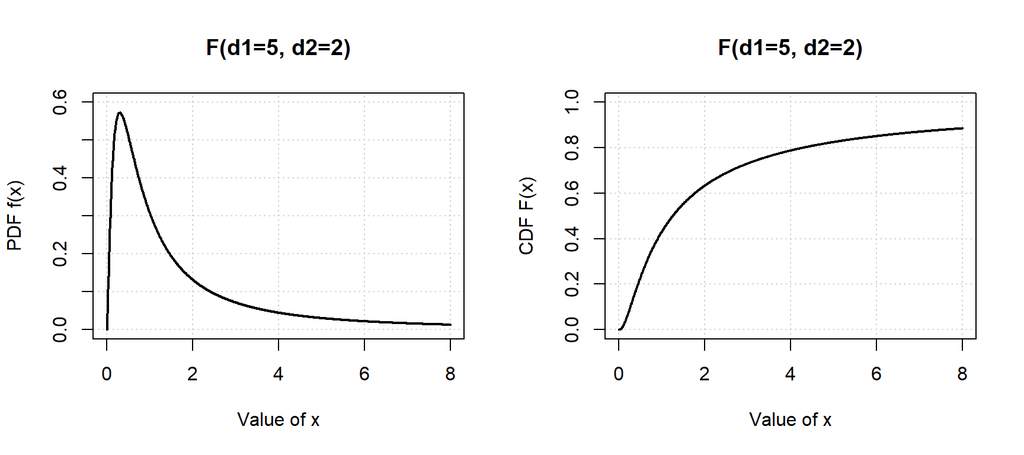

```r
# Simulate F(5,2) observations
d1 <- 5
d2 <- 2
rf(5, df1 = d1, df2 = d2)
```

```
[1] 17.377144  0.882152  1.536231  4.487365  1.777715
```

- Probability density function $f_X$ is right-skewed and unimodal.
- Mean $\mathbb{E}(X)$ is
  $$\mathbb{E}(X) = \frac{d_2}{d_2-2}\quad\text{for
  }d_2>2$$
- As $d_2\rightarrow\infty$, the denominator of an F-distributed random variable becomes
  $$C_2/d_2 = \frac{1}{d_2}\sum_{i=1}^{d_2} Z_i^2
  \rightarrow \mathbb{E}(Z_i^2)=1\quad\text{as
  }d_2\rightarrow\infty$$
  based on the [law of large numbers LLN](https://en.wikipedia.org/wiki/Law_of_large_numbers). In this case, the F-distributed random variable is
  $$X = \frac{C_1 / d_1}{C_2 / d_2}\approx
  \frac{C_1}{d_1} \overset{d}{=} \frac{1}{d_1}\mathcal{X}^2_{d_1}$$
  i.e. it converges to a scaled $\mathcal{X}^2$-distribution with $d_1$ degrees of freedom (with scaling of $1/d_1$). In other words,
  $$F_{d_1,d_2}\overset{d}{\approx}\frac{1}{d_1}\mathcal{X}^2_{d_1}\quad\text{for
  large } d_2$$
- In practice, F-distribution is mostly used in statistical hypothesis testing e.g. **F-test** to select between two nested statistical models later.

## 5.7 Model Selection with F-Test and ${\small t}$-Test

- In machine learning modeling, there is always a trade-off between goodness-of-fit of a model to the training data vs **model complexity**. A complex model (e.g. too many explanatory variables, categorical variable with too many levels i.e. high cardinality, or highly nonlinear) might overfit / memorize the observed data and fail to recognize the general pattern for unseen data. **Model selection** strives to find the simplest model that fits the observed data adequately.
- In statistical linear regression modeling, one main tool for model selection is to conduct hypothesis tests called the **F-test**. It is specifically for comparing a larger model vs a smaller model that is nested within. (Technically, a **nested model** is obtained by imposing some linear constraint(s) to restrict the parameters $\beta_0,\dotsc,\beta_d$ of the larger model.) Here are some examples of nested models:
  1. Decide if one (or more) explanatory variable(s) should be included in a model or not e.g.
     $$\begin{align}
     Y = \beta_0 + \beta_1 x_1 + \beta_2 x_2 +
     \epsilon\quad&\text{vs}\quad Y = \beta_0 + \beta_1 x_1 + \epsilon\\
     H_0: \beta_2 = 0\quad&\text{vs}\quad H_1: \beta_2 \neq 0
     \end{align}$$
  2. Decide if a higher degree term is needed in a polynomial regression e.g.
     $$\begin{align}
     Y = \beta_0 + \beta_1 x + \beta_2 x^2 + \beta_3 x^3 +
     \epsilon\quad&\text{vs}\quad Y = \beta_0 + \beta_1 x + \beta_2 x^2 +
     \epsilon\\
     H_0: \beta_3 = 0\quad&\text{vs}\quad H_1: \beta_3 \neq 0
     \end{align}$$
  3. Decide if an interaction term is useful in a model or not e.g.
     $$\begin{align}
     Y = \beta_0 + \beta_1 x_1 + \beta_2 x_2 + \beta_3 x_1 x_2 +
     \epsilon\quad&\text{vs}\quad Y = \beta_0 + \beta_1 x_1 + \beta_2 x_2
     + \epsilon\\
     H_0: \beta_3 = 0\quad&\text{vs}\quad H_1: \beta_3 \neq 0
     \end{align}$$
  4. Decide if two (or more) levels of a categorical variable should be combined or not e.g.
     $$\begin{align}
     Y = \beta_0 + \beta_1 x_1 + \beta_2 \mathbf{1}_{\{\text{Windy}\}} +
     \beta_3 \mathbf{1}_{\{\text{Cloudy}\}} +
     \epsilon\quad&\text{vs}\quad Y = \beta_0 + \beta_1 x_1 + \beta_2
     \mathbf{1}_{\{\text{Windy}\}} + \beta_2 \mathbf{1}_{\{\text{Cloudy}\}} +
     \epsilon\\
     H_0: \beta_2 = \beta_3 \quad&\text{vs}\quad H_1: \beta_2 \neq
     \beta_3
     \end{align}$$
  5. **Omnibus F-test:** Decide if any explanatory variable is useful in the model at all e.g.
     $$Y =
     \beta_0 + \beta_1 x_1 + \beta_2 x_2 + \beta_3 x_3 +
     \epsilon\quad\text{vs}\quad Y = \beta_0 + \epsilon$$
     $$H_0: \beta_1 = \beta_2 = \beta_3 =
     0\quad\text{vs}\quad H_1: \text{ some }\beta_j \neq 0$$
- Let $SS_\text{error}^\text{large}$ and $SS_\text{error}^\text{small}$ be the residual sums of squares (represent goodness-of-fit) of the larger and smaller nested model repsectively. Let
  $$p^\text{large} > p^\text{small}$$
  be their model degrees of freedom (represent model complexity). Since the larger model is more flexible and can behave like the smaller nested model if it wants to, it would not fit the observed data worse than the smaller model. Therefore, it must have higher $R^2$ and lower $SS_\text{error}$ and MSE i.e.
  $$SS_\text{error}^\text{large} <
  SS_\text{error}^\text{small}$$
- We are interested in whether the reduction in $SS_\text{error}$ is significant enough to worth the increase in the number of model parameters $p$. To do so, let us consider the F-test statistic
  $$\text{f} = \left.
  \left(\frac{SS_\text{error}^\text{small} -
  SS_\text{error}^\text{large}}{(n - p^\text{small}) - (n -
  p^\text{large})} \right)\right/
  \left(\frac{SS_\text{error}^\text{large}}{n - p^\text{large}}\right) =
  \left.\left(\frac{SS_\text{error}^\text{small} -
  SS_\text{error}^\text{large}}{p^\text{large} - p^\text{small}}\right)
  \right/\left( \frac{SS_\text{error}^\text{large}}{n -
  p^\text{large}}\right)$$
  It represents the relative reduction in $SS_\text{error}$ benchmarked against the number of model parameters.
- Under the null hypothesis $H_0$ that the smaller nested model suffices, we have the reference probability distribution
  $$\text{f}\sim
  F_{(p^\text{large} - p^\text{small}),\,(n -
  p^\text{large})}\quad\text{under }H_0$$
  If $H_0$ is false, then the smaller model is insufficient so it yields large $SS_\text{error}^\text{small} \gg SS_\text{error}^\text{large}$. As a result, the F-test statistic $\text{f}\gg 0$. Therefore, we compute p-value based on the right-tail of the corresponding F-distribution and reject $H_0$ if the value of $\text{f}$ is large. If we want significance level at $\alpha\%$, then we use the $(1-\alpha)\%$-tile $\text{f}_{1 - \alpha}$ as the rejection threshold.

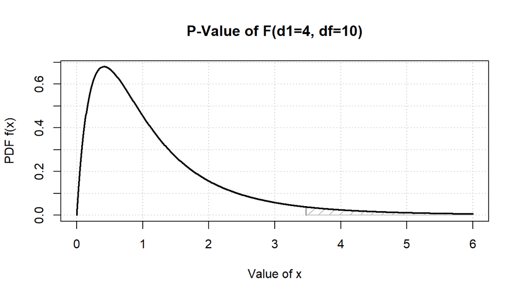

- *Example:* Below is an example to perform the omnibus F-test found in `summary(model)` for the null hypothesis $H_0: \beta_1=\dotsc=\beta_d = 0$.

```r
# Omnibus F-test
set.seed(1)

n <- 100
x1 <- runif(n)
x2 <- runif(n)
y <- 1 + 0 * x1 + 2 * x2 + rnorm(n, sd = 0.5)

large.model <- lm(y ~ x1 + x2)
summary(large.model)
```

```
Call:
lm(formula = y ~ x1 + x2)

Residuals:
    Min      1Q  Median      3Q     Max
-0.9290 -0.3084 -0.0716  0.2676  1.1659

Coefficients:
            Estimate Std. Error t value Pr(>|t|)
(Intercept)  0.99532    0.13953   7.133 1.77e-10 ***
x1          -0.03463    0.18172  -0.191    0.849
x2           2.00718    0.17889  11.220  < 2e-16 ***
---
Signif. codes:  0 '***' 0.001 '**' 0.01 '*' 0.05 '.' 0.1 ' ' 1

Residual standard error: 0.4838 on 97 degrees of freedom
Multiple R-squared:  0.5648,    Adjusted R-squared:  0.5558
F-statistic: 62.94 on 2 and 97 DF,  p-value: < 2.2e-16
```

```r
small.model <- lm(y ~ 1) # H0: b1 = b2 = 0
summary(small.model)
```

```
Call:
lm(formula = y ~ 1)

Residuals:
     Min       1Q   Median       3Q      Max
-1.44921 -0.57786 -0.02299  0.56204  1.50374

Coefficients:
            Estimate Std. Error t value Pr(>|t|)
(Intercept)  2.01604    0.07259   27.77   <2e-16 ***
---
Signif. codes:  0 '***' 0.001 '**' 0.01 '*' 0.05 '.' 0.1 ' ' 1

Residual standard error: 0.7259 on 99 degrees of freedom
```

```r
anova(small.model, large.model) # Not to be confused with aov()
```

```
Analysis of Variance Table

Model 1: y ~ 1
Model 2: y ~ x1 + x2
  Res.Df   RSS Df Sum of Sq      F    Pr(>F)
1     99 52.16
2     97 22.70  2     29.46 62.943 < 2.2e-16 ***
---
Signif. codes:  0 '***' 0.001 '**' 0.01 '*' 0.05 '.' 0.1 ' ' 1
```

```r
# Compute F-statistic and p-value manually
(ss.error.large <- deviance(large.model))
p.large <- 3

(ss.error.small <- deviance(small.model))
p.small <- 1

(f <- ((ss.error.small - ss.error.large) / (p.large - p.small)) / (ss.error.large / (n - p.large)))

(p.value <- 1 - pf(f, p.large - p.small, n - p.large))
```

```
[1] 22.70011
[1] 52.16008
[1] 62.94282
[1] 0
```

- *Example:* Below is an example to perform F-test for the null hypothesis $H_0: \beta_j = 0$ to decide to select the explanatory variable $x_j$ or not.

```r
set.seed(1)

n <- 100
x1 <- runif(n)
x2 <- runif(n)
y <- 1 + 0 * x1 + 2 * x2 + rnorm(n, sd = 0.5)

large.model <- lm(y ~ x1 + x2)
summary(large.model)
```

```
Call:
lm(formula = y ~ x1 + x2)

Residuals:
    Min      1Q  Median      3Q     Max
-0.9290 -0.3084 -0.0716  0.2676  1.1659

Coefficients:
            Estimate Std. Error t value Pr(>|t|)
(Intercept)  0.99532    0.13953   7.133 1.77e-10 ***
x1          -0.03463    0.18172  -0.191    0.849
x2           2.00718    0.17889  11.220  < 2e-16 ***
---
Signif. codes:  0 '***' 0.001 '**' 0.01 '*' 0.05 '.' 0.1 ' ' 1

Residual standard error: 0.4838 on 97 degrees of freedom
Multiple R-squared:  0.5648,    Adjusted R-squared:  0.5558
F-statistic: 62.94 on 2 and 97 DF,  p-value: < 2.2e-16
```

```r
small.model <- update(large.model, . ~ . - x1) # Modify the model formula and refit
summary(small.model)
```

```
Call:
lm(formula = y ~ x2)

Residuals:
     Min       1Q   Median       3Q      Max
-0.93937 -0.30670 -0.06959  0.26911  1.17215

Coefficients:
            Estimate Std. Error t value Pr(>|t|)
(Intercept)   0.9777     0.1039   9.408 2.34e-15 ***
x2            2.0066     0.1780  11.274  < 2e-16 ***
---
Signif. codes:  0 '***' 0.001 '**' 0.01 '*' 0.05 '.' 0.1 ' ' 1

Residual standard error: 0.4814 on 98 degrees of freedom
Multiple R-squared:  0.5646,    Adjusted R-squared:  0.5602
F-statistic: 127.1 on 1 and 98 DF,  p-value: < 2.2e-16
```

```r
anova(small.model, large.model)
```

```
Analysis of Variance Table

Model 1: y ~ x2
Model 2: y ~ x1 + x2
  Res.Df    RSS Df Sum of Sq      F Pr(>F)
1     98 22.709
2     97 22.700  1 0.0084993 0.0363 0.8493
```

- *Example:* Below is an example to perform sequential F-tests to decide the degree of a polynomial regression. This works because `anova(model)` will perform an incremental F-test for each additional explanatory variable $x_j = x^j$ that appears in the model formula.

```r
x <- c(-0.47, -0.26, 0.15, 0.82, -0.6, 0.80, 0.89, 0.32)
y <- c(0.25, -0.02, 0.07, 0.74, 0.41, 0.60, 0.94, 0.14)
```

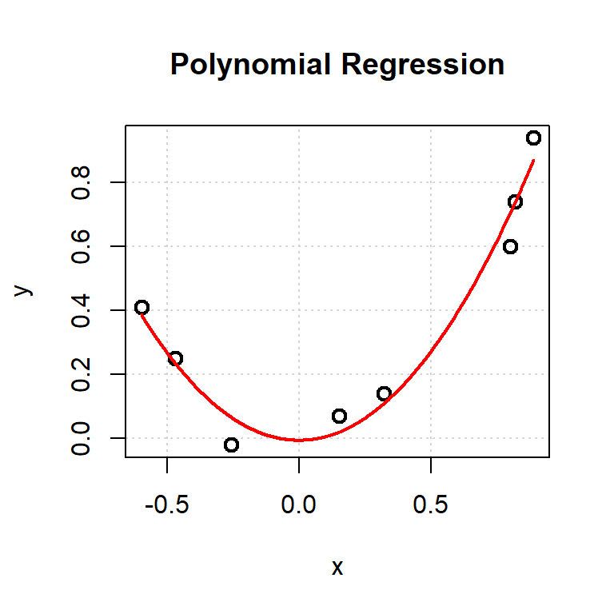

```r
model <- lm(y ~ x + I(x ^ 2) + I(x ^ 3) + I(x ^ 4))
summary(model)
```

```
Call:
lm(formula = y ~ x + I(x^2) + I(x^3) + I(x^4))

Residuals:
        1         2         3         4         5         6         7         8
 0.064391 -0.047974  0.001283  0.031879 -0.028174 -0.055377  0.014006  0.019966

Coefficients:
            Estimate Std. Error t value Pr(>|t|)
(Intercept)  0.03396    0.05198   0.653    0.560
x            0.19594    0.15809   1.239    0.303
I(x^2)       0.32877    0.50045   0.657    0.558
I(x^3)      -0.85442    0.49158  -1.738    0.181
I(x^4)       1.68878    0.90312   1.870    0.158

Residual standard error: 0.06304 on 3 degrees of freedom
Multiple R-squared:  0.9855,    Adjusted R-squared:  0.9662
F-statistic: 50.97 on 4 and 3 DF,  p-value: 0.004327
```

```r
anova(model)
```

```
Analysis of Variance Table

Response: y
          Df  Sum Sq Mean Sq  F value   Pr(>F)
x          1 0.37449 0.37449  94.2444 0.002321 **
I(x^2)     1 0.42035 0.42035 105.7851 0.001960 **
I(x^3)     1 0.00143 0.00143   0.3593 0.591136
I(x^4)     1 0.01389 0.01389   3.4967 0.158262
Residuals  3 0.01192 0.00397
---
Signif. codes:  0 '***' 0.001 '**' 0.01 '*' 0.05 '.' 0.1 ' ' 1
```

```r
anova(lm(y ~ poly(x, 5, raw = TRUE)))
```

```
Analysis of Variance Table

Response: y
                       Df  Sum Sq Mean Sq F value  Pr(>F)
poly(x, 5, raw = TRUE)  5 0.81701 0.16340   64.33 0.01538 *
Residuals               2 0.00508 0.00254
---
Signif. codes:  0 '***' 0.001 '**' 0.01 '*' 0.05 '.' 0.1 ' ' 1
```

- *Example:* Below is an example to perform F-test to decide to select (all levels of) a categorical variable or not.

```r
set.seed(2)

n <- 100
temperature <- runif(n, min = 0, max = 100)
weather <- sample(c('Sunny', 'Windy', 'Cloudy'), n, replace = TRUE)
weather.offset <- numeric(length(temperature))
weather.offset[weather == 'Sunny'] <- 1
weather.offset[weather == 'Windy'] <- -2
weather.offset[weather == 'Cloudy'] <- -2
feel <- temperature + weather.offset + rnorm(n, sd = 5)

large.model <- lm(feel ~ temperature + weather)
summary(large.model)
```

```
Call:
lm(formula = feel ~ temperature + weather)

Residuals:
    Min      1Q  Median      3Q     Max
-9.7972 -4.0050  0.7037  3.4849 13.2348

Coefficients:
             Estimate Std. Error t value Pr(>|t|)
(Intercept)  -3.34919    1.23868  -2.704  0.00811 **
temperature   1.01901    0.01717  59.348  < 2e-16 ***
weatherSunny  3.62232    1.21055   2.992  0.00352 **
weatherWindy  0.79247    1.29197   0.613  0.54108
---
Signif. codes:  0 '***' 0.001 '**' 0.01 '*' 0.05 '.' 0.1 ' ' 1

Residual standard error: 5.018 on 96 degrees of freedom
Multiple R-squared:  0.9747,    Adjusted R-squared:  0.9739
F-statistic:  1232 on 3 and 96 DF,  p-value: < 2.2e-16
```

- Since the categorical variable `weather` has 3 levels, the larger model is
  $$Y = \beta_0 +
  \beta_1\,(\text{temperature}) + \beta_2 \,\mathbf{1}_\text{\{Sunny\}}+
  \beta_3 \,\mathbf{1}_\text{\{Windy\}}+\epsilon$$
  In this case, the null hypothesis is
  $$H_0: \beta_2 =
  \beta_3 = 0$$
  i.e. none of `Sunny` or `Windy` is different from the baseline categorical level of `Cloudy` in the intercept term.

```r
small.model <- lm(feel ~ temperature)
summary(small.model)

anova(small.model, large.model)
```

```
Call:
lm(formula = feel ~ temperature)

Residuals:
     Min       1Q   Median       3Q      Max
-10.5479  -3.8432   0.6347   3.0454  14.8833

Coefficients:
            Estimate Std. Error t value Pr(>|t|)
(Intercept) -2.03001    1.00953  -2.011   0.0471 *
temperature  1.02575    0.01758  58.360   <2e-16 ***
---
Signif. codes:  0 '***' 0.001 '**' 0.01 '*' 0.05 '.' 0.1 ' ' 1

Residual standard error: 5.221 on 98 degrees of freedom
Multiple R-squared:  0.972, Adjusted R-squared:  0.9717
F-statistic:  3406 on 1 and 98 DF,  p-value: < 2.2e-16

Analysis of Variance Table

Model 1: feel ~ temperature
Model 2: feel ~ temperature + weather
  Res.Df    RSS Df Sum of Sq      F   Pr(>F)
1     98 2671.1
2     96 2416.9  2    254.16 5.0477 0.008234 **
---
Signif. codes:  0 '***' 0.001 '**' 0.01 '*' 0.05 '.' 0.1 ' ' 1
```

- *Example:* Below is an example to perform F-test to decide to combine some levels of a categorical variable or not. Continuing from the larger model
  $$Y = \beta_0 +
  \beta_1\,(\text{temperature}) + \beta_2 \,\mathbf{1}_\text{\{Sunny\}}+
  \beta_3 \,\mathbf{1}_\text{\{Windy\}}+\epsilon$$
  Now the null hypothesis is $H_0: \beta_3 = 0$ i.e. `Windy` should not have its own $\beta_3 \,\mathbf{1}_\text{\{Windy\}}$ term and should be collapsed into the intercept term shared by `Cloudy` instead.

```r
weather.c <- weather
weather.c[weather.c == 'Cloudy'] = 'Cloudy or Windy'
weather.c[weather.c == 'Windy'] = 'Cloudy or Windy'
small.model <- lm(feel ~ temperature + weather.c)
summary(small.model)
```

```
Call:
lm(formula = feel ~ temperature + weather.c)

Residuals:
    Min      1Q  Median      3Q     Max
-9.8551 -3.7343  0.6198  3.4539 13.2811

Coefficients:
               Estimate Std. Error t value Pr(>|t|)
(Intercept)    -2.90973    1.00720  -2.889  0.00477 **
temperature     1.01792    0.01702  59.797  < 2e-16 ***
weather.cSunny  3.24233    1.03668   3.128  0.00233 **
---
Signif. codes:  0 '***' 0.001 '**' 0.01 '*' 0.05 '.' 0.1 ' ' 1

Residual standard error: 5.001 on 97 degrees of freedom
Multiple R-squared:  0.9746,    Adjusted R-squared:  0.9741
F-statistic:  1860 on 2 and 97 DF,  p-value: < 2.2e-16
```

```r
anova(small.model, large.model)
```

```
Analysis of Variance Table

Model 1: feel ~ temperature + weather.c
Model 2: feel ~ temperature + weather
  Res.Df    RSS Df Sum of Sq      F Pr(>F)
1     97 2426.4
2     96 2416.9  1    9.4722 0.3762 0.5411
```

- To decide to select an explanatory variable $x_j$ or not, we focus on the null hypothesis $H_0: \beta_j = 0$. Previously, we conduct this hypothesis testing using the F-test, which evaluates if the reduction in $SS_\text{error}$ by the larger model with $\beta_j\neq 0$ is worth the increase in the $+1$ number of model parameters vs the smaller model with $\beta_j = 0$.
- Besides the F-test, an alternative (and mathematically equivalent) way to conduct this hypothesis testing is to use the $t$-test to evaluate directly if the model parameter estimate $\hat{\beta}_j$ is statistically significantly different from $0$ or not. To do so:
  1. Compute standard error of the $\hat{\beta_j}$ estimator
     $$\text{s.e.}(\hat{\beta}_j) = \hat{\sigma}
     \sqrt{(X^T X)^{-1}_{ii}}$$
     This comes from the multivariate normal distribution of the MLE estimator $\vec{\beta}^*_\text{MLE}$.
  2. Compute $t$-statistic
     $$t_j = \frac{\hat{\beta}_j -
     0}{\text{s.e.}(\hat{\beta}_j)} = \frac{\hat{\beta}_j}{\hat{\sigma}
     \sqrt{(X^T X)^{-1}_{ii}}}\sim t_{n - p}\quad\text{under }H_0: \beta_j =
     0$$
  3. Compute (two-sided) p-value using the reference probability distribution $t_{n-p}$ with $\nu = n-p$ residual degrees of freedom. This kind of hypothesis testing is called a **Wald test**.
- The `Pr(>|t|)` column of `summary(model)` provides a quick overview of individual hypothesis tests $H_0: \beta_j = 0$ for each model parameter $\beta_j$.

```r
set.seed(1)

n <- 100
x1 <- runif(n)
x2 <- runif(n)
y <- 1 + 0 * x1 + 2 * x2 + rnorm(n, sd = 0.5)

model <- lm(y ~ x1 + x2)
summary(model)
```

```
Call:
lm(formula = y ~ x1 + x2)

Residuals:
    Min      1Q  Median      3Q     Max
-0.9290 -0.3084 -0.0716  0.2676  1.1659

Coefficients:
            Estimate Std. Error t value Pr(>|t|)
(Intercept)  0.99532    0.13953   7.133 1.77e-10 ***
x1          -0.03463    0.18172  -0.191    0.849
x2           2.00718    0.17889  11.220  < 2e-16 ***
---
Signif. codes:  0 '***' 0.001 '**' 0.01 '*' 0.05 '.' 0.1 ' ' 1

Residual standard error: 0.4838 on 97 degrees of freedom
Multiple R-squared:  0.5648,    Adjusted R-squared:  0.5558
F-statistic: 62.94 on 2 and 97 DF,  p-value: < 2.2e-16
```

```r
# Step 1: Compute standard error for beta
X <- model.matrix(y ~ x1 + x2)
C.unscaled <- solve(t(X) %*% X) # Also summary(model)$cov.unscaled

sigma <- summary(model)$sigma
C <- sigma ^ 2 * C.unscaled # Cov(estimated beta)  Also vcov(model)
(s.e.beta <- sqrt(diag(C))) # s.e.(beta)
```

```
(Intercept)          x1          x2
  0.1395314   0.1817239   0.1788948
```

```r
# Step 2: Compute t-statistic
beta <- coef(model)
(t.stat <- beta / s.e.beta)
```

```
(Intercept)          x1          x2
  7.1332728  -0.1905738  11.2198767
```

```r
# Step 3: Compute (two-sided) p-value using reference t-distribution
(p.value <- 2 * pt(abs(t.stat), df = df.residual(model), lower.tail = FALSE))
```

```
 (Intercept)           x1           x2
1.771804e-10 8.492578e-01 3.196083e-19
```

- Why is this $t$-test equivalent to the corresponding F-test? First, the F-test statistic and the $t$-statistic are related by
  $$\text{f} = t_j^2$$

```r
large.model <- lm(y ~ x1 + x2)
small.model <- lm(y ~ x2) # H0: b1 = 0
(f.test <- anova(small.model, large.model))

(f.stat <- f.test$F[2]) # F-test statistic
```

```
Analysis of Variance Table

Model 1: y ~ x2
Model 2: y ~ x1 + x2
  Res.Df    RSS Df Sum of Sq      F Pr(>F)
1     98 22.709
2     97 22.700  1 0.0084993 0.0363 0.8493
[1] 0.03631838
```

```r
summary(large.model)

t.stat <- coef(summary(large.model))[2,3] # t-statistic
t.stat ^ 2
```

```
Call:
lm(formula = y ~ x1 + x2)

Residuals:
    Min      1Q  Median      3Q     Max
-0.9290 -0.3084 -0.0716  0.2676  1.1659

Coefficients:
            Estimate Std. Error t value Pr(>|t|)
(Intercept)  0.99532    0.13953   7.133 1.77e-10 ***
x1          -0.03463    0.18172  -0.191    0.849
x2           2.00718    0.17889  11.220  < 2e-16 ***
---
Signif. codes:  0 '***' 0.001 '**' 0.01 '*' 0.05 '.' 0.1 ' ' 1

Residual standard error: 0.4838 on 97 degrees of freedom
Multiple R-squared:  0.5648,    Adjusted R-squared:  0.5558
F-statistic: 62.94 on 2 and 97 DF,  p-value: < 2.2e-16

[1] 0.03631838
```

- Secondly, the p-value computed from the right-tail of the $F_{1,n-p}$ distribution is same as the two-sided p-value computed from the $t_{n-p}$ distribution.

```r
pf(f.stat, df1 = 1, df2 = df.residual(large.model), lower.tail = FALSE)
2 * pt(abs(t.stat), df = df.residual(large.model), lower.tail = FALSE)
```

```
[1] 0.8492578
[1] 0.8492578
```

- The F-test is more general. Its null hypothesis can involve more complex relationship across multiple model parameters $\beta_j$’s. On the other hand, a $t$-test only concerns about if a particular model parameter $b_j = 0$ or not.
- For each $t$-test, the interpretation of the null hypothesis $H_0: \beta_j=0$ is “if all other explanatory variables are already present in the model, then is $\beta_j$ still useful or not?” This means:
  1. The set of individual $t$-tests are separate and not related to each other e.g. not sequential.
  2. If an explanatory variable is added to or removed from the model, then the $t$-tests and p-values for other explanatory variables usually change.

```r
x1 <- c(-0.55, 0.86, 1.31, 1.48, -0.10, 2.41, 1.33, 0.04, -1.59, 1.19)
x2 <- c(0.22, 0.36, 1.52, 1.73, 0.80, 1.82, 1.73, 0.74, -1.36, 0.68)
y <- c(0.44, 3.48, 5.23, 8.20, 4.02, 13.99, 8.64, 4.06, -6.36, 2.66)

summary(lm(y ~ x1 + x2))
```

```
Call:
lm(formula = y ~ x1 + x2)

Residuals:
    Min      1Q  Median      3Q     Max
-2.6879 -0.5385  0.1398  0.7764  3.1883

Coefficients:
            Estimate Std. Error t value Pr(>|t|)
(Intercept)   0.5827     0.8455   0.689   0.5129
x1            1.7067     1.1484   1.486   0.1808
x2            3.3549     1.3880   2.417   0.0463 *
---
Signif. codes:  0 '***' 0.001 '**' 0.01 '*' 0.05 '.' 0.1 ' ' 1

Residual standard error: 1.881 on 7 degrees of freedom
Multiple R-squared:  0.905, Adjusted R-squared:  0.8778
F-statistic: 33.33 on 2 and 7 DF,  p-value: 0.0002645
```

```r
summary(lm(y ~ x1))
```

```
Call:
lm(formula = y ~ x1)

Residuals:
    Min      1Q  Median      3Q     Max
-4.0746 -1.7899  0.6044  1.9162  2.6572

Coefficients:
            Estimate Std. Error t value Pr(>|t|)
(Intercept)   1.7792     0.8685   2.049 0.074670 .
x1            4.1642     0.6765   6.155 0.000272 ***
---
Signif. codes:  0 '***' 0.001 '**' 0.01 '*' 0.05 '.' 0.1 ' ' 1

Residual standard error: 2.383 on 8 degrees of freedom
Multiple R-squared:  0.8257,    Adjusted R-squared:  0.8039
F-statistic: 37.89 on 1 and 8 DF,  p-value: 0.0002724
```

```r
summary(lm(y ~ x2))
```

```
Call:
lm(formula = y ~ x2)

Residuals:
    Min      1Q  Median      3Q     Max
-2.8120 -0.9142 -0.3908  0.4043  4.3937

Coefficients:
            Estimate Std. Error t value Pr(>|t|)
(Intercept)   0.1668     0.8560   0.195     0.85
x2            5.1810     0.6924   7.483 7.04e-05 ***
---
Signif. codes:  0 '***' 0.001 '**' 0.01 '*' 0.05 '.' 0.1 ' ' 1

Residual standard error: 2.018 on 8 degrees of freedom
Multiple R-squared:  0.875, Adjusted R-squared:  0.8594
F-statistic:    56 on 1 and 8 DF,  p-value: 7.04e-05
```

- If there is (near) multicollinearity among some explanatory variables, then the $t$-test’s p-values might seem misleading (unless you understand its proper interpretation).

```r
set.seed(1)

n <- 100
x1 <- runif(n)
x2 <- x1 + rnorm(n, sd = 0.001)
y <- 1 + 1 * x1 + 1 * x2 + rnorm(n, sd = 0.1)

cor(x1, x2)
```

```
[1] 0.9999939
```

```r
summary(lm(y ~ x1 + x2)) # Both x1 and x2 have large p-values
```

```
Call:
lm(formula = y ~ x1 + x2)

Residuals:
     Min       1Q   Median       3Q      Max
-0.28311 -0.07273 -0.00537  0.06338  0.23359

Coefficients:
            Estimate Std. Error t value Pr(>|t|)
(Intercept)  1.01305    0.02319  43.688   <2e-16 ***
x1          -6.11730   11.34084  -0.539    0.591
x2           8.09674   11.33723   0.714    0.477
---
Signif. codes:  0 '***' 0.001 '**' 0.01 '*' 0.05 '.' 0.1 ' ' 1

Residual standard error: 0.1056 on 97 degrees of freedom
Multiple R-squared:  0.9626,    Adjusted R-squared:  0.9618
F-statistic:  1248 on 2 and 97 DF,  p-value: < 2.2e-16
```

```r
summary(lm(y ~ x1))
```

```
Call:
lm(formula = y ~ x1)

Residuals:
      Min        1Q    Median        3Q       Max
-0.288231 -0.068074 -0.007586  0.061531  0.241729

Coefficients:
            Estimate Std. Error t value Pr(>|t|)
(Intercept)  1.01160    0.02304   43.90   <2e-16 ***
x1           1.98197    0.03957   50.09   <2e-16 ***
---
Signif. codes:  0 '***' 0.001 '**' 0.01 '*' 0.05 '.' 0.1 ' ' 1

Residual standard error: 0.1054 on 98 degrees of freedom
Multiple R-squared:  0.9624,    Adjusted R-squared:  0.962
F-statistic:  2509 on 1 and 98 DF,  p-value: < 2.2e-16
```

```r
summary(lm(y ~ x2))
```

```
Call:
lm(formula = y ~ x2)

Residuals:
      Min        1Q    Median        3Q       Max
-0.286993 -0.068484 -0.007379  0.061259  0.237965

Coefficients:
            Estimate Std. Error t value Pr(>|t|)
(Intercept)  1.01191    0.02301   43.98   <2e-16 ***
x2           1.98142    0.03951   50.15   <2e-16 ***
---
Signif. codes:  0 '***' 0.001 '**' 0.01 '*' 0.05 '.' 0.1 ' ' 1

Residual standard error: 0.1052 on 98 degrees of freedom
Multiple R-squared:  0.9625,    Adjusted R-squared:  0.9621
F-statistic:  2515 on 1 and 98 DF,  p-value: < 2.2e-16
```

- The $t$-test for an individual categorical level is a comparison with the baseline categorical level only (in case when the model has an intercept term). If you would like to decide to select the entire categorical variable or not, then do a F-test using the `anova()` function instead.

```r
set.seed(2)

n <- 100
temperature <- runif(n, min = 0, max = 100)
weather <- sample(c('Sunny', 'Windy', 'Cloudy'), n, replace = TRUE)
weather.offset <- numeric(length(temperature))
weather.offset[weather == 'Sunny'] <- 1
weather.offset[weather == 'Windy'] <- -2
weather.offset[weather == 'Cloudy'] <- -2
feel <- temperature + weather.offset + rnorm(n, sd = 5)

summary(lm(feel ~ temperature + weather))
```

```
Call:
lm(formula = feel ~ temperature + weather)

Residuals:
    Min      1Q  Median      3Q     Max
-9.7972 -4.0050  0.7037  3.4849 13.2348

Coefficients:
             Estimate Std. Error t value Pr(>|t|)
(Intercept)  -3.34919    1.23868  -2.704  0.00811 **
temperature   1.01901    0.01717  59.348  < 2e-16 ***
weatherSunny  3.62232    1.21055   2.992  0.00352 **
weatherWindy  0.79247    1.29197   0.613  0.54108
---
Signif. codes:  0 '***' 0.001 '**' 0.01 '*' 0.05 '.' 0.1 ' ' 1

Residual standard error: 5.018 on 96 degrees of freedom
Multiple R-squared:  0.9747,    Adjusted R-squared:  0.9739
F-statistic:  1232 on 3 and 96 DF,  p-value: < 2.2e-16
```

## 5.8 Information Criteria and Adjusted ${\small R^2}$

- Since the F-test (and hence $t$-test) for model selection is only applicable to comparison between two nested models, we need some other metrics to select between two competing models in general:
  1. **Akaike Information Criterion AIC:** It is motivated by [information theory](https://en.wikipedia.org/wiki/Information_theory) to measure the distance between the fitted model vs the unknown true model. We want to minimize
     $$\text{AIC} = -2\,\log(L) + 2\,p$$
     Here $L$ is the likelihood function value of the fitted linear regression model evaluated at the MLEs from the observed data (so the $1^\text{st}$ term represents goodness-of-fit). Moreover, $p = d + 2$ is the total number of parameters in the model, which counts all of $\beta_0,\dotsc,\beta_d,\sigma^2$ (so the $2^\text{nd}$ term represents model complexity).
  2. **Bayes Information Criterion BIC:** It is defined based on the [Bayesian framework](https://en.wikipedia.org/wiki/Bayesian_inference) to approximate the [posterior probability](https://en.wikipedia.org/wiki/Posterior_probability) of the observed data under the fitted model. We want to minimize
     $$\text{BIC} = -2\,\log(L) + \log(n)
     \,p$$
  3. **Adjusted $R^2$:** Since the coefficient of determination $R^2$ never decreases with more explanatory variable(s) in a linear regression model, it cannot be used for model selection. To introduce a model complexity trade-off to the $R^2$ formula, we modify it by dividing each of its $SS_\text{error}$ and $SS_\text{total}$ by their corresponding residual degrees of freedom $n-p$ and $n-1$ respectively. We want to maximize
     $$\text{adjusted } R^2 = 1 -
     \frac{SS_\text{error}/(n-p)}{SS_\text{total}/(n-1)} = 1 -
     \frac{\hat{\sigma}^2_\text{model}}{\hat{\sigma}^2_\text{null}}\in(-\infty,R^2]$$
     Unlike AIC and BIC defintions above, here $p=1+d$ does not count the $\sigma^2$ parameter for the variance of the noise term $\epsilon$.

```r
x <- c(-0.55, 0.86, 1.31, 1.48, -0.10, 2.41, 1.33, 0.04, -1.59, 1.19)
y <- c(0.44, 3.48, 5.23, 8.20, 4.02, 13.99, 8.64, 4.06, -6.36, 2.66)
model <- lm(y ~ x)

# Compute log-likelihood
logLik(model)
```

```
'log Lik.' -21.75862 (df=3)
```

```r
# Compute log-likelihood manually
n <- length(y)
sigma.mle <- sqrt(mean(residuals(model) ^ 2)) # Unadjusted sigma from MLE
(log.L <- -(n / 2) * log(2 * pi * sigma.mle ^ 2) - 1 / (2 * sigma.mle ^ 2) * sum(residuals(model) ^ 2))
```

```
[1] -21.75862
```

```r
# Compute AIC
AIC(model) # See also extractAIC()
```

```
[1] 49.51725
```

```r
# Compute AIC manually
p <- 2 + 1 # Count all of b0, b1, and sigma
-2 * log.L + 2 * p
```

```
[1] 49.51725
```

```r
# Compute BIC
AIC(model, k = log(n)) # -2 * log(L) + k * p where k = log(n)
```

```
[1] 50.425
```

```r
# Compute BIC manually
-2 * log.L + log(n) * p
```

```
[1] 50.425
```

```r
# Compute adjusted R^2
summary(model)
summary(model)$adj.r.squared

# Compute adjusted R^2 manually
ss.error <- sum(residuals(model) ^ 2)
ss.total <- sum((y - mean(y)) ^ 2)
p <- 2 # Count b0 and b1 but not sigma
(adj.r2 <- 1 - (ss.error / (n - p)) / (ss.total / (n - 1)))
```

```
Call:
lm(formula = y ~ x)

Residuals:
    Min      1Q  Median      3Q     Max
-4.0746 -1.7899  0.6044  1.9162  2.6572

Coefficients:
            Estimate Std. Error t value Pr(>|t|)
(Intercept)   1.7792     0.8685   2.049 0.074670 .
x             4.1642     0.6765   6.155 0.000272 ***
---
Signif. codes:  0 '***' 0.001 '**' 0.01 '*' 0.05 '.' 0.1 ' ' 1

Residual standard error: 2.383 on 8 degrees of freedom
Multiple R-squared:  0.8257,    Adjusted R-squared:  0.8039
F-statistic: 37.89 on 1 and 8 DF,  p-value: 0.0002724

[1] 0.8038707
[1] 0.8038707
```

- Now you should know the meaning and computation of every number shown in `summary(model)`.
- Which of these AIC, BIC, and adjusted $R^2$ metrics should we use in practice?
  - For AIC (and similarly BIC), different software tools might compute the log-likelihood values differently (up to an additive constant). Therefore, AIC values are intended to be compared relatively only (so the additive constant would be cancelled out anyway). An individual AIC value of a model might not have much meaning. In particular, there is no concept of a “large enough” AIC value that would indicate if a model is good enough or not.
  - For sufficiently large data set, we have $\log(n) > 2$. In this case, BIC penalizes model complexity more severely (i.e. prefers a simpler model) than AIC.
  - For adjusted $R^2$, it is essentially determined by the numerator $SS_\text{error}/(n-p) = \hat{\sigma}^2_\text{model}$ since the denominator $SS_\text{total} / (n-1)$ does not change across models.
  - For large data set with $n \gg 0$, $R^2\approx$ adjusted $R^2$ since the ratio $(n-p)/(n-1)\approx 1$.
  - In theory, AIC and BIC have different asymptotic optimality behaviors. In practice, it is best to try all these metrics and see which models each metric selects, and also which explanatory variables are common or different among these selected models in order to obtain insight on the importance of each explanatory variable.

## 5.9 Forward, Backward, and Stepwise Regression

- If there are $d$ possible explanatory variables $\vec{x} = (x_1,\dotsc,x_d)\in\mathbb{R}^d$ (including variable transformation, polynomial term, interaction term, and one-hot encoding of categorical level), and each explanatory variable might or might not be selected, then there are $2^d$ possible linear regression models to be considered.
- It is usually too time-consuming and not practical to fit all of the models in order to perform F-test or compute AIC, BIC, and adjusted $R^2$ metrics to select the best model.
- We often use some **[greedy algorithm](https://en.wikipedia.org/wiki/Greedy_algorithm)** to explore strategically only a subset of all possible models. (In general, a heuristic or procedure is “greedy” if it is myopic / short-sighted i.e. it makes incremental optimal choices locally with the hope that these individual choices together would be near the global optimum.) The most common algorithmic procedures for model selection are:
  1. **Forward selection**
     - Start with the simplest null linear regression model i.e. with intercept term only without any explanatory variable.
     - Iteratively, select the next most useful explanatory variable (that is not yet in the model) and include it in the model. Here “most useful” can be defined as the explanatory variable with the highest statistical significance i.e. smallest p-value in a F-test or $t$-test against the current smaller nested model of selected explanatory variables, or would improve AIC / BIC / adjusted $R^2$ metric the most.
     - Stop when there is no more useful explanatory variable to be included into the model. This could be based on a significance level threshold on p-value e.g. $\alpha = 0.2$, or no more improvement in AIC / BIC / adjusted $R^2$ metric.
  2. **Backward elimination**
     - Start with the most complex full linear regression model with all of the explanatory variables.
     - Iteratively, identify the least useful explanatory variable (that is still in the model) and remove it from the model.
     - Stop when there is no more useless explanatory variable to be removed from the model.
  3. **[Stepwise selection](https://en.wikipedia.org/wiki/Stepwise_regression)**
     - (This is just a hybrid of forward selection and backward elimination.)
     - Start with either the null or full linear regression model.
     - Iteratively, either select the most useful explanatory variable (that is not in the model, maybe removed previously) to be included in the model, or select the least useful explanatory variable (that is currently in the model) to be removed from the model.
- Which model selection procedure should we use?
  - Forward selection only selects explanatory variables one at a time. If there is a pair of explanatory variables $x_1$ and $x_2$ that are very useful together but each is individually not as useful as another explanatory variable $x_3$, then $x_3$ might be selected instead of $x_1$ and $x_2$. This is a typical shortcoming of greedy algorithm.
  - Backward elimination has a slight advantage that it can see how all the explanatory variables work together in the initial full model. So it can make better decision on which explanatory variable to be removed. However, if there are too many explanatory variables to begin with, then it might not even be feasible to fit the full model.
  - Both forward selection and backward elimination handle multicollinearity well. If an explanatory variable is redundant, then it is unlikely to be selected in forward selection, and it is likely to be removed in backward elimination.
  - Different model selection procedures might yield different final models. In practice, besides comparing the sets of explanatory variables in these final models, we also obtain insight about the relative importance of the explanatory variables from the order of selections and removals.
- In R, use `add1()`, `drop1()`, and `step()` functions for stepwise regression.

```r
# Simulate some observed data
set.seed(1)

n <- 100
x1 <- runif(n)
x2 <- runif(n)
x3 <- x1 + x2 + rnorm(n, sd = 0.1) # Multicollinear with x1 and x2
y <- 1 + x1 + x2 + rnorm(n)

cor(x1 + x2, x3)
```

```
[1] 0.9702168
```

```r
full.model <- lm(y ~ x1 + x2 + x3)
summary(full.model) # Large p-values due to multicollinearity
```

```
Call:
lm(formula = y ~ x1 + x2 + x3)

Residuals:
     Min       1Q   Median       3Q      Max
-2.92961 -0.45913  0.00181  0.65546  2.61178

Coefficients:
            Estimate Std. Error t value Pr(>|t|)
(Intercept)   1.0381     0.3025   3.431 0.000887 ***
x1            1.4854     1.1619   1.278 0.204213
x2            1.5706     1.1686   1.344 0.182105
x3           -0.5380     1.1007  -0.489 0.626091
---
Signif. codes:  0 '***' 0.001 '**' 0.01 '*' 0.05 '.' 0.1 ' ' 1

Residual standard error: 1.049 on 96 degrees of freedom
Multiple R-squared:  0.1222,    Adjusted R-squared:  0.09476
F-statistic: 4.454 on 3 and 96 DF,  p-value: 0.00565
```

```r
# One iteration of forward selection
null.model <- lm(y ~ 1)
add1(null.model, scope = ~ x1 + x2 + x3, k = 2, test = 'F') # Use k = log(n) for BIC
```

```
Single term additions

Model:
y ~ 1
       Df Sum of Sq    RSS    AIC F value    Pr(>F)
<none>              120.32 20.495
x1      1    6.6544 113.66 16.805  5.7375 0.0185062 *
x2      1    8.0292 112.29 15.588  7.0076 0.0094584 **
x3      1   12.6747 107.64 11.363 11.5394 0.0009858 ***
---
Signif. codes:  0 '***' 0.001 '**' 0.01 '*' 0.05 '.' 0.1 ' ' 1
```

- Here `add1(..., test = 'F')` means R would report p-value based on F-test. However, the stepwise regression `step()` variable selection logic is always based on AIC (when `k = 2`) or BIC (when `k = log(n)`) information criteria metric instead.

```r
# Forward selection
step(null.model, scope = ~ x1 + x2 + x3 , direction = 'forward', k = 2, trace = 1)

# One iteration of backward elimination
drop1(full.model, k = 2, test = 'F')

# Backward elimination
step(full.model, direction = 'backward', k = 2, test = 'F', trace = 1)
```

```
Start:  AIC=20.49
y ~ 1

       Df Sum of Sq    RSS    AIC
+ x3    1   12.6747 107.64 11.363
+ x2    1    8.0292 112.29 15.588
+ x1    1    6.6544 113.66 16.805
<none>              120.32 20.495

Step:  AIC=11.36
y ~ x3

       Df Sum of Sq    RSS    AIC
<none>              107.64 11.363
+ x2    1  0.229172 107.41 13.150
+ x1    1  0.039638 107.60 13.326

Call:
lm(formula = y ~ x3)

Coefficients:
(Intercept)           x3
     1.1315       0.9049

Single term deletions

Model:
y ~ x1 + x2 + x3
       Df Sum of Sq    RSS    AIC F value Pr(>F)
<none>              105.61 13.462
x1      1   1.79780 107.41 13.150  1.6341 0.2042
x2      1   1.98733 107.60 13.326  1.8064 0.1821
x3      1   0.26286 105.88 11.711  0.2389 0.6261
Start:  AIC=13.46
y ~ x1 + x2 + x3

       Df Sum of Sq    RSS    AIC F value Pr(>F)
- x3    1   0.26286 105.88 11.711  0.2389 0.6261
- x1    1   1.79780 107.41 13.150  1.6341 0.2042
- x2    1   1.98733 107.60 13.326  1.8064 0.1821
<none>              105.61 13.462

Step:  AIC=11.71
y ~ x1 + x2

       Df Sum of Sq    RSS    AIC F value   Pr(>F)
<none>              105.88 11.711
- x1    1    6.4096 112.29 15.588  5.8722 0.017236 *
- x2    1    7.7844 113.66 16.805  7.1317 0.008881 **
---
Signif. codes:  0 '***' 0.001 '**' 0.01 '*' 0.05 '.' 0.1 ' ' 1

Call:
lm(formula = y ~ x1 + x2)

Coefficients:
(Intercept)           x1           x2
      1.039        0.951        1.032
```

- Forward selection and backward elimination are conceptually simple, easy to implement, and generally applicable to any machine learning modeling given a model evaluation metric. However, in order to decide which explanatory variable should be added or removed, we need to fit up to $d$ models. This might be too computationally-intensive. In modern machine learning, there are other more advanced techniques (e.g. LASSO) that could perform similar kind of variable selection by fitting just one model.

## 5.10 Model Diagnostic

- A statistical procedure (such as confidence interval construction or hypothesis testing) is **properly calibrated** if its probabilistic claims are accurate e.g. a 95% confidence interval that indeed contains the true parameter 95% of the time, or a hypothesis test at $\alpha = 10\%$ significance level that indeed makes a type I mistake 10% of the time.
- Proper calibration requires a statistical model and its assumptions to be valid.
- Linear regression model diagnostics focus mostly on the residual values $r_1,\dotsc,r_n$ of a fitted model.
- The following sections are in the order of practical importance from modern machine learning modeling perspective. Here are some considerations:
  - Predictive performance is usually the most important i.e. low MSE and high $R^2$ and adjusted $R^2$. Good predictive performance mostly comes from useful explanatory variables and feature engineering i.e. suitable transformation of explanatory variables $\vec{x}$ and response $y$.
  - For large data set, it is more likely to have outliers and anomalies. It also has higher statistical power to detect even small violation. Therefore, it is more difficult to satisfy all of the model assumptions.
  - Nonetheless, a fitted model that violates some model assumptions can still be useful e.g. to represent the relationship between the explanatory variables $\vec{x}$ and response $y$, or have good predictive performance.

### 5.10.1 Linear Relationship

- The main assumption of linear regression model is that each explanatory variable $x_j$ is linearly related to the response $y$. In this case, there should not be any systemic under- or over-prediction. The residuals should not have systemic positive and negative values in a plot vs each $x_j$.

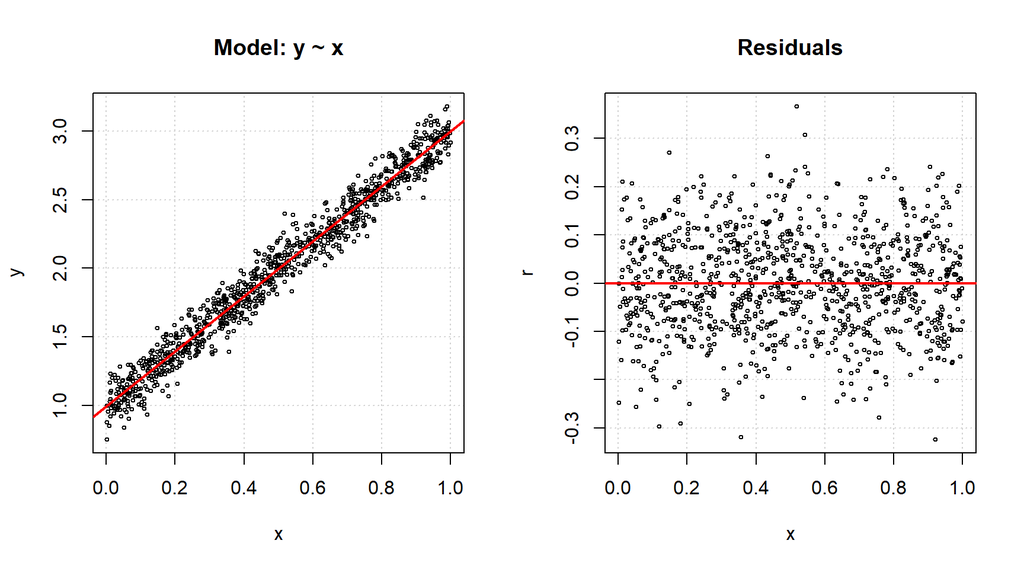

```r
n <- 1000
x <- runif(n)
y <- 1 + 2 * x + rnorm(n, sd = 0.1)

model <- lm(y ~ x)
r <- residuals(model)

plot(x, y, type = 'p', main = 'Linear Regression')
abline(model)

plot(x, r, type = 'p', main = 'Residuals')
abline(a = 0, b = 0)
```

- If the linear assumption is violated, then the residuals might exhibit systemic positive and negative values in a plot vs some $x_j$.
- One remedy is to perform additional feature engineering e.g. introduce polynomial term (such as $x^k$), transformation (such as $\sqrt{x}$ or $\log x$), or interaction term to represent more complex mathematical relationship.

```r
n <- 1000
x <- runif(n)
y <- x ^ 2 + rnorm(n, sd = 0.1)

model <- lm(y ~ x)
r <- residuals(model)
```

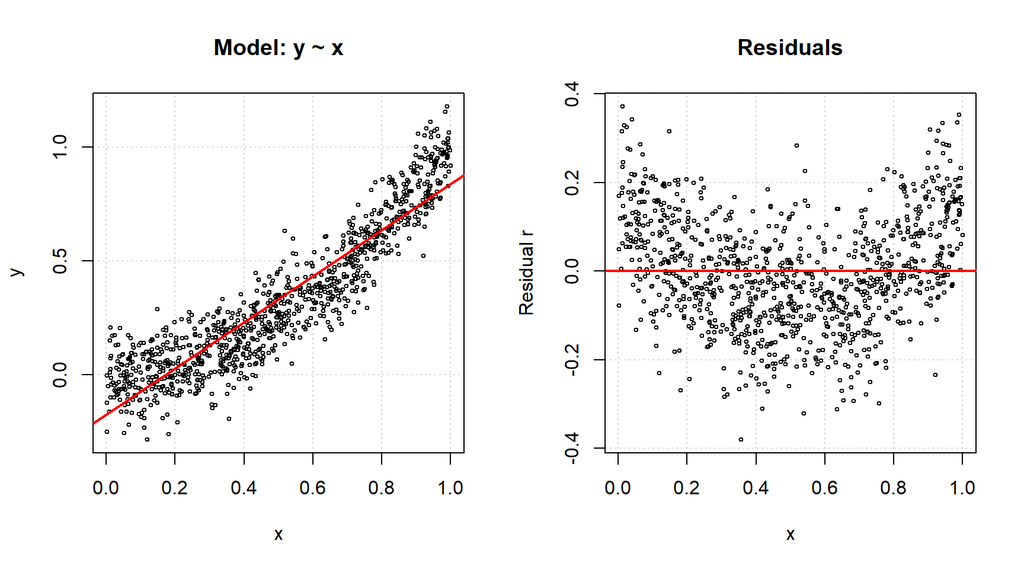

### 5.10.2 Homoscedasticity

- **[Homoscedasticity](https://en.wikipedia.org/wiki/Homoscedasticity_and_heteroscedasticity)** refers to the assumption of constant variance across all response values
  $$\text{Var}(Y_1) = \dotsc = \text{Var}(Y_n)
  = \sigma^2$$
- Such assumption might be inappropriate due to the nature of the observed data. In many cases, the variance $\text{Var}(Y_i)$ increases with the response value $y_i$. For example:
  - $x$ = house size, $y$ = house price
  - $x$ = age of a person, $y$ = net worth
  - $x$ = distance of a taxi trip, $y$ = trip duration
- If the constant variance assumption does not hold, then it is called **heteroscedasticity**.
- To identify heteroscedasticity, we usually plot the residual values of a fitted model against either the response variable $y$ or any explanatory variable $x_j$ and look for any systemic non-constant pattern.

```r
n <- 1000
x <- runif(n, min = 30, max = 65)
b0 <- 0.2
b1 <- 1.05
y <- b0 * b1 ^ x * exp(rnorm(n, sd = 0.5))

model <- lm(y ~ x)
r <- residuals(model)
```

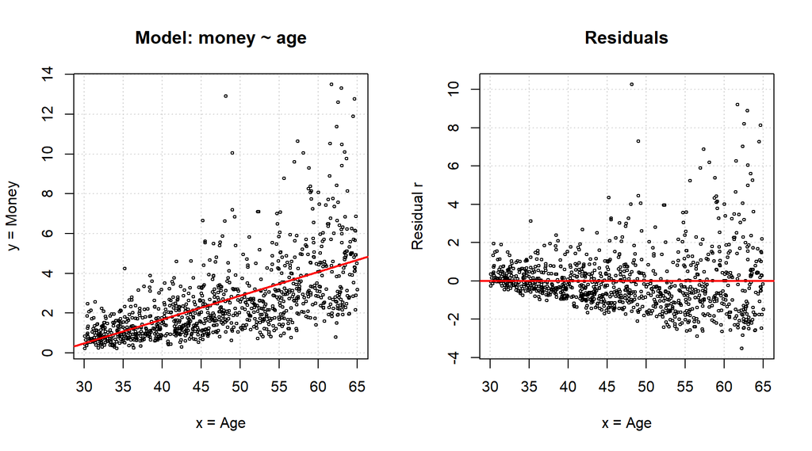

- There is also formal hypothesis test such as the [Bresuch-Pagan test](https://en.wikipedia.org/wiki/Breusch%E2%80%93Pagan_test) in R’s `lmtest::bptest()` for detecting heteroskedasticity.
- If heteroskedasticity is a result of the [exponential growth](https://en.wikipedia.org/wiki/Exponential_growth) phenomenon with multiplicative error term $\epsilon$ (instead of additive error term i.e. $+\,\epsilon$)
  $$Y =
  \beta_0\times(\beta_1)^x\times\epsilon$$
  then the variance
  $$\text{Var}(Y) =
  \beta_0^2\times(\beta_1)^{2x}\times\text{Var} (\epsilon)$$
  indeed increases with $y$ even if $\text{Var}(\epsilon) = \sigma^2$ is constant. As a remedy, we take logarithm of both sides of the model equation so it becomes
  $$\log Y =
  \log(\beta_0) + \log(\beta_1)\,x + \log(\epsilon)$$
  Now it can be fitted as a linear regression model `lm(log(y) ~ x)`.
- Note that `lm(log(y) ~ x)` is not the same as `lm(y ~ exp(x))`. The latter has model equation
  $$Y = \beta_0 + \beta_1 (e^x) + \epsilon$$
  which is the usual kind of linear regression model with an additive error term and an exponential variable transformation on $x$.
- Similarly, if the multiplicative relationship between the explanatory variable $x$ and response variable $y$ is
  $$Y = \beta_0\times
  x^{\beta_1}\times\epsilon$$
  then taking logarithm would yield the linear regression model
  $$\log Y =
  \log(\beta_0) + \beta_1 \log(x) + \log(\epsilon)$$
  i.e. `lm(log(y) ~ log(x))`.

```r
model <- lm(log(y) ~ x)
r <- residuals(model)

exp(coef(model)) # Estimates of b0 and b1
```

```
(Intercept)           x
   0.194744    1.050318
```

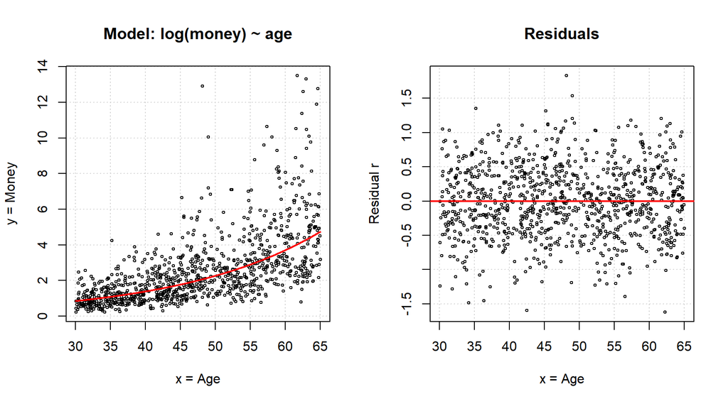

- Not all heteroskedasticity could be addressed by transforming the response variable $y$. For example, $\log(y)$ or $\sqrt{y}$ is only applicable to $y > 0$.
- Another remedy is the [**weighted least squares**](https://en.wikipedia.org/wiki/Weighted_least_squares) technique. If each error term $\epsilon_i$ has a different variance
  $$\text{Var}(\epsilon_i) = \sigma_i^2$$
  but this variance is known (i.e. no longer an unknown model parameter), then the log-likelihood function of the statistical linear regression model is
  $$l(\beta_0,\dotsc,\beta_d)
  = (\text{constant})
  -\underbrace{\frac{1}{2\sigma_i^2}}_{w_i}\sum_{i=1}^n \left( y_i -
  (\beta_0 + \beta_1 x_{i1} + \dotsb + \beta_d x_{id})\right)^2$$
  This is a weighted sum of squares of the residuals with weight $w_i = 1/(2\sigma^2_i)$. In general, the weighted-version of the mean squared error MSE is
  $$\min_{\beta_0,\dotsc,\beta_d}\,\underbrace{\frac{1}{n}\sum_{i=1}^n
  w_i \big(y_i - (\beta_0 + \beta_1 x_{i1}+\dotsb+\beta_d
  x_{id})\big)^2}_\text{weighted MSE}$$
  There exists closed-form formula and efficient computational technique to solve it for $\vec{\beta}^*$. Intuitively, if a data point has high variance i.e. large $\sigma_i^2$, then it would have small weight $w_i$ so the weighted least squares optimization focuses less on this data point.

### 5.10.3 Normality

- The “square” in mean squared error MSE and least squares LS are motivated by the normality assumption on the error term
  $$\epsilon_i \sim\mathcal{N}(0,\sigma^2)$$
  and the corresponding mathematical form of the likelihood function.
- We assess the normality assumption of the (unobserved) $\epsilon_i$’s by examining the fitted residuals $r_i$’s. (Strictly speaking, the $r_i$’s are just a proxy. They are slightly correlated i.e. not independent. Their variances are also not exactly $\sigma^2$.)
  $$\text{Var}(r_i) = \sigma^2 (1 - h_{ii})\neq
  \sigma^2\quad\text{where} \quad H = X(X^T X)^{-1} X^T$$
- Besides plotting a histogram of the residuals $r_i$’s and look for a bell-shape, we can also use the [**Q-Q plot**](https://en.wikipedia.org/wiki/Q%E2%80%93Q_plot). It provides a clearer visual comparison between the observed data sample (in our case, the residuals) vs the quantiles of a given reference probability distribution.
- In R, use `qqnorm()` (or more generally `qqplot()`) and `qqline()`.

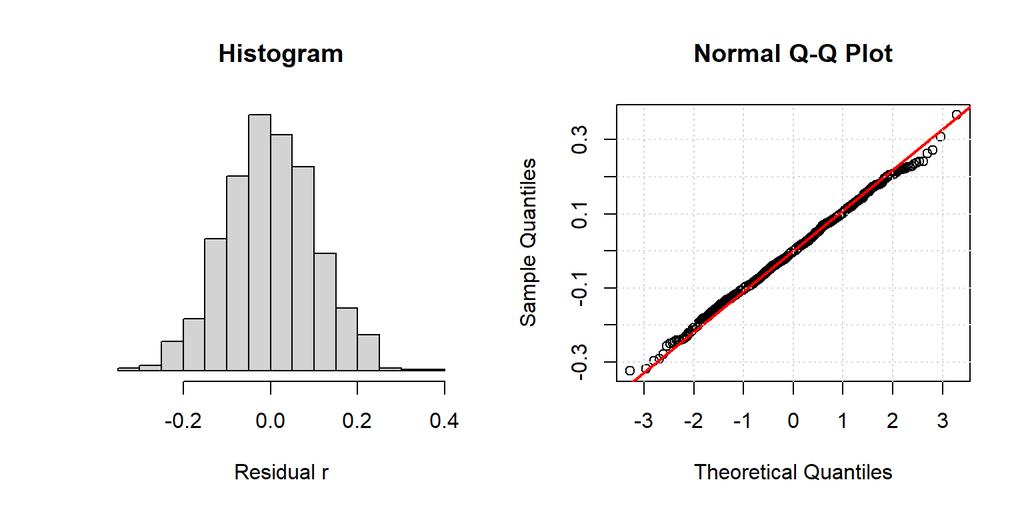

```r
n <- 1000
x <- runif(n)
y <- 1 + 2 * x + rnorm(n, sd = 0.1)

model <- lm(y ~ x)
r <- residuals(model)

hist(r)

qqnorm(r)
qqline(r, col = 'red', lwd = 2)
grid()
```

- If the residuals are normally distributed, then the points on the Q-Q plot should fall along a straight line. (This line does not need to be exactly the diagonal $y = x$ line.)
- Note that a histogram of the observed responses $y_i$’s does not necessarily have a bell-shape. Although each response random variable $Y_i\sim\mathcal{N}(\mu_i,\sigma^2)$ is normally distributed, each has its own expectation $\mathbb{E}(Y_i)=\mu_i$. So they are not a sample from one common normal distribution.
- Below are some examples of Q-Q plot which compare data samples from a thin-tail $\text{Unif}(0,1)$ distribution, a fat-tail $t_{\nu = 2}$ distribution, and a right-skewed $\mathcal{X}^2_{k=5}$ distribution, each against the standard normal $\mathcal{N}(0,1)$ distribution. Note the specific ways these plots deviate from a straight line.

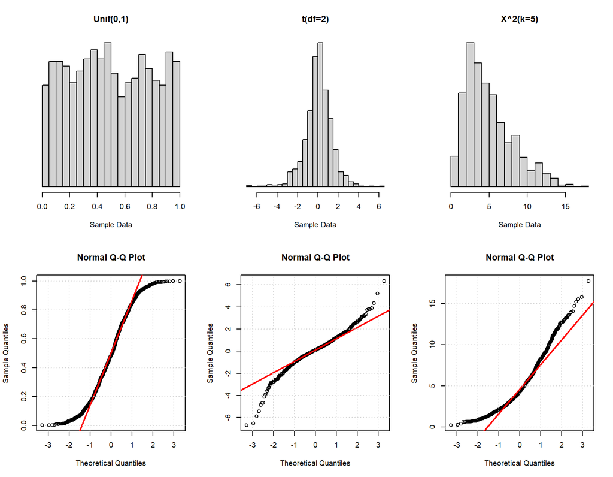

- There are also many [normality tests](https://en.wikipedia.org/wiki/Normality_tests) developed by statisticians over the years. See R’s `library(nortest)`. e.g.
  - [Kolmogorov–Smirnov Test](https://en.wikipedia.org/wiki/Kolmogorov%E2%80%93Smirnov_test) (1939) `ks.test()`
  - [Anderson–Darling test](https://en.wikipedia.org/wiki/Anderson%E2%80%93Darling_test) (1952)
  - [Shapiro–Wilk test](https://en.wikipedia.org/wiki/Shapiro%E2%80%93Wilk_test) (1965) `shapiro.test()` and its variant [Shapiro–Francia test](https://en.wikipedia.org/wiki/Shapiro%E2%80%93Francia_test) (1972)
  - [Lilliefors test](https://en.wikipedia.org/wiki/Lilliefors_test) (1967)
  - [Jarque–Bera test](https://en.wikipedia.org/wiki/Jarque%E2%80%93Bera_test) (1980)

```r
x <- rnorm(100, mean = 2, sd = 3)

ks.test(x, pnorm, mean = mean(x), sd = sd(x)) # Need to specific the exact reference distribution
shapiro.test(x)
```

```
    Asymptotic one-sample Kolmogorov-Smirnov test

data:  x
D = 0.047014, p-value = 0.9799
alternative hypothesis: two-sided


    Shapiro-Wilk normality test

data:  x
W = 0.9956, p-value = 0.9876
```

```r
x <- runif(100)

ks.test(x, pnorm, mean = mean(x), sd = sd(x))
shapiro.test(x)
```

```
    Asymptotic one-sample Kolmogorov-Smirnov test

data:  x
D = 0.089053, p-value = 0.4059
alternative hypothesis: two-sided


    Shapiro-Wilk normality test

data:  x
W = 0.95935, p-value = 0.003613
```

```r
x <- rt(100, df = 2)

ks.test(x, pnorm, mean = mean(x), sd = sd(x))
shapiro.test(x)
```

```
    Asymptotic one-sample Kolmogorov-Smirnov test

data:  x
D = 0.32428, p-value = 1.47e-09
alternative hypothesis: two-sided


    Shapiro-Wilk normality test

data:  x
W = 0.4308, p-value < 2.2e-16
```

```r
x <- rchisq(100, df = 5)
ks.test(x, pnorm, mean = mean(x), sd = sd(x))
shapiro.test(x)
```

```
    Asymptotic one-sample Kolmogorov-Smirnov test

data:  x
D = 0.081988, p-value = 0.5122
alternative hypothesis: two-sided


    Shapiro-Wilk normality test

data:  x
W = 0.97129, p-value = 0.02779
```

- What is the issue with violating the normality assumption?
  - If the violation is due to some large (positive or negative) residuals i.e. outliers, then we should revisit our fitted model. Perhaps we should consider other [robust regression](https://en.wikipedia.org/wiki/Robust_regression) techniques that are less sensitive to outliers.
  - Improper calibration of confidence interval, hypothesis testing, and p-values.

# 6 Logistic Regression

- [**Logistic regression**](https://en.wikipedia.org/wiki/Logistic_regression) is one of the simplest linear models for binary classification. The name “regression” is misleading since it is actually for classification task (with $y\in\{0,1\}$) and not regression task (for $y\in\mathbb{R}$).
- In statistics and machine learning literature, the logistic regression model can be formulated and viewed in multiple ways:
  1. (Statistics) it is one kind of [generalized linear model GLM](https://en.wikipedia.org/wiki/Generalized_linear_model) involving the Bernoulli or binomial distribution within the [exponential family](https://en.wikipedia.org/wiki/Exponential_family).
  2. (Statistics) It can be viewed as a latent variable model that thresholds a real-valued random variable as a binary response.
  3. (Machine learning) It can be viewed as a linear combination of input features with [sigmoid](https://en.wikipedia.org/wiki/Sigmoid_function) transformation and log loss.
  4. (Machine learning) It can be implemented as a 1-layer fully-connected feed-forward neural net with [softmax](https://en.wikipedia.org/wiki/Softmax_function) activation function and [cross-entropy](https://en.wikipedia.org/wiki/Cross-entropy) loss objective function.

## 6.1 Binary Classification

- For a machine learning predictive task with explanatory variable $\vec{x}\in\mathbb{R}^d$ and response variable $y$, if the response variable $y\in\{c_1,\dotsc,c_k\}$ is categorical / discrete, then it is a **classification** task.
- Moreover, if there are only $k=2$ classes so $y\in\{c_1,c_2\}$ is binary / **dichotomous** i.e. it takes one of only two possible distinct values / **class labels**, then it is a **binary** classification task.
- *Example:* Let $x\in[0,\infty)$ be the number of hours of studying and $y\in\{\text{pass},\text{fail}\}$ be the outcome of an exam.

```r
study <- c(0.13, 0.23, 0.62, 1.08, 1.26, 1.77, 1.86, 2.02, 2.06, 2.12,
           2.66, 2.67, 3.40, 3.72, 3.80, 3.82, 3.84, 3.86, 4.11, 4.77,
           4.82, 4.94, 4.98, 5.30, 5.53, 5.73, 6.00, 6.29, 6.47, 6.52,
           6.61, 6.68, 6.87, 6.93, 7.18, 7.24, 7.32, 7.70, 7.77, 7.83,
           7.89, 7.94, 8.21, 8.27, 8.70, 8.98, 9.08, 9.35, 9.45, 9.92)
exam <- c(0, 0, 0, 0, 0, 0, 0, 0, 0, 0,
          1, 0, 0, 0, 1, 0, 0, 1, 0, 1,
          0, 1, 0, 1, 1, 0, 0, 1, 0, 0,
          1, 0, 1, 1, 0, 1, 1, 1, 1, 1,
          1, 1, 1, 0, 1, 1, 1, 1, 1, 1) # 1 is pass and 0 is fail
```

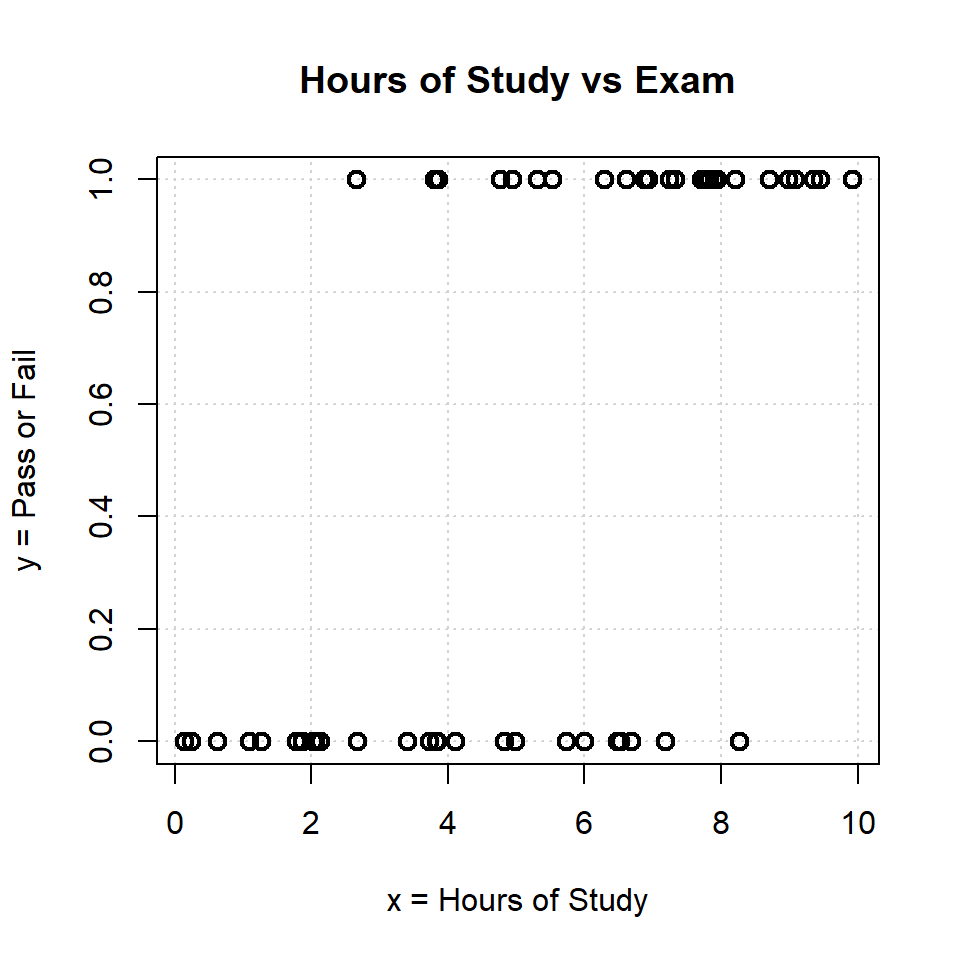

- *Example:* Let $\vec{x}\in\mathbb{R}^d$ be the word frequencies of $d$ pre-defined words of interest in an email and $y\in\{\text{legitimate},\text{spam}\}$.